# Differential Abundance Analysis (DAA): Lung Tissue

Eva Kim

12/09/2024

Based on the alpha and beta diversity results, I am not expecting to find a huge difference between groups in terms of bacterial composition. Please note that many of these code are from the Microbiome Intensive Course (MIC Course, Duke University, 2023) and thus the work of [Dr. Pixu Shi](https://scholars.duke.edu/person/Pixu.Shi).

This is after talking with Dr. Shi about what analyses I want to run.

# 1 Set-Up

First, update the `ANCOMBC` package if necessary.

```r
#if (!requireNamespace("BiocManager", quietly=TRUE))
#     install.packages("BiocManager")
#BiocManager::install("ANCOMBC")
```

## 1.1 Load libraries and directories

```r
# rm(list = ls(all = TRUE)) ## Unload all packages if necessary
library(phyloseq)
library(fs)
library(rstatix)
library(ggpubr)
library(microViz)
library(ANCOMBC)
library(pals)
library(RColorBrewer)
library(colorBlindness)
library(microbiome)
library(ggrepel)
library(DT)
library(plotly)
library(DESeq2)
library(parallel)
library(dplyr)
library(tidyr)
library(readr)
library(tibble)
library(stringr)
library(ggtext)
library(doBy)
```

```r
rm(list=ls()) # clear environment

git.dir = file.path("/hpc/group/dmc/Eva/GLP_KO_Microbiome_final") # CHANGE ME
ps.rds <- file.path(git.dir, "ps.GLP1.rds")
ps <- read_rds(ps.rds)
ps
```

```
## phyloseq-class experiment-level object
## otu_table()   OTU Table:         [ 3304 taxa and 234 samples ]
## sample_data() Sample Data:       [ 234 samples by 42 sample variables ]
## tax_table()   Taxonomy Table:    [ 3304 taxa by 6 taxonomic ranks ]
## phy_tree()    Phylogenetic Tree: [ 3304 tips and 3303 internal nodes ]
## refseq()      DNAStringSet:      [ 3304 reference sequences ]
```

```r
fig.dir = file.path(git.dir, "figures")

map.file = file.path(git.dir, "Metadata_GLP1.csv")
meta.df = read_csv(map.file, show_col_types = FALSE)
```

# 2 Prepare phyloseq object

I will now aggregate at the genus level, as it is the smallest taxonomic rank that analyses will be run on. In other words, I do not plan on running differential abundance analysis at ASV level.

Furthermore, categorical variables should be re-leveled as factors.

```r
# Subset to true lung tissue samples only and remove tree
ps  %>% subset_samples(Sample_type == "Lung Tissue" & Type == "True Sample") -> ps_lt
ps_lt_notree <- phyloseq(otu_table(ps_lt), tax_table(ps_lt), sample_data(ps_lt))

# Categorical variables should be factors
ps_lt_notree@sam_data$Genotype <- factor(ps_lt_notree@sam_data$Genotype, levels = c("WT", "KO"))
ps_lt_notree@sam_data$Sex <- factor(ps_lt_notree@sam_data$Sex, levels = c("Female", "Male"))
ps_lt_notree@sam_data$Intranasal_Treatment <- factor(ps_lt_notree@sam_data$Intranasal_Treatment, levels = c("PBS", "HDM"))
ps_lt_notree@sam_data$Surgery <- factor(ps_lt_notree@sam_data$Surgery, levels = c("None", "Sham", "VSG"))
ps_lt_notree@sam_data$Mouse %>% unique() -> mouse_levels
ps_lt_notree@sam_data$Mouse <- factor(ps_lt_notree@sam_data$Mouse, levels = mouse_levels)
ps_lt_notree@sam_data$Diet <- factor(ps_lt_notree@sam_data$Diet, levels = c("Normal_Chow", "High_Fat_Diet"))
ps_lt_notree@sam_data$Group <- factor(ps_lt_notree@sam_data$Group, levels = c("NA", "Control", "1", "2"))

ps_lt_notree
```

```
## phyloseq-class experiment-level object
## otu_table()   OTU Table:         [ 3304 taxa and 44 samples ]
## sample_data() Sample Data:       [ 44 samples by 42 sample variables ]
## tax_table()   Taxonomy Table:    [ 3304 taxa by 6 taxonomic ranks ]
```

```r
# Aggregate at genus level
ps_g_notree_LT <- tax_glom(ps_lt_notree, "Genus")
taxa_names(ps_g_notree_LT) <- tax_table(ps_g_notree_LT)[, 'Genus']

ps_g_notree_LT
```

```
## phyloseq-class experiment-level object
## otu_table()   OTU Table:         [ 314 taxa and 44 samples ]
## sample_data() Sample Data:       [ 44 samples by 42 sample variables ]
## tax_table()   Taxonomy Table:    [ 314 taxa by 6 taxonomic ranks ]
```

```r
ps_g_notree_LT %>% transform_sample_counts(function(x) x/sum(x)) -> ps_genus.ts
ps_genus.ts
```

```
## phyloseq-class experiment-level object
## otu_table()   OTU Table:         [ 314 taxa and 44 samples ]
## sample_data() Sample Data:       [ 44 samples by 42 sample variables ]
## tax_table()   Taxonomy Table:    [ 314 taxa by 6 taxonomic ranks ]
```

## 2.1 Getting ready: prune data

We will prune the phyloseq object at each phylogenetic rank at and above genus. Since we plan on running correlation analysis after differential abundance, let’s test for taxa that are present in at least 5 samples (arbitrary number) with greater than 10 reads in each sample (also arbitrary. It’s also 1% of 1000 reads, which was the threshold used to remove samples from analysis).

### 2.1.1 Genus

```r
# Pruning: set threshold number
threshold_num = 4
nreads_prune = 10

# Prune taxa at each phylogenetic rank
ps_g_notree_LT %>%
  filter_taxa(., function(x) {sum(x > nreads_prune) > threshold_num}, prune = TRUE) -> ps_genus.prune
ps_genus.prune
```

```
## phyloseq-class experiment-level object
## otu_table()   OTU Table:         [ 52 taxa and 44 samples ]
## sample_data() Sample Data:       [ 44 samples by 42 sample variables ]
## tax_table()   Taxonomy Table:    [ 52 taxa by 6 taxonomic ranks ]
```

```r
subset_taxa(ps_genus.ts, ps_genus.ts@tax_table[, "Genus"] %in% ps_genus.prune@tax_table[, "Genus"]) -> ps_genus.prune.ts
ps_genus.prune.ts
```

```
## phyloseq-class experiment-level object
## otu_table()   OTU Table:         [ 52 taxa and 44 samples ]
## sample_data() Sample Data:       [ 44 samples by 42 sample variables ]
## tax_table()   Taxonomy Table:    [ 52 taxa by 6 taxonomic ranks ]
```

```r
rowSums(ps_genus.prune.ts@otu_table) %>% as.data.frame() %>%
  dplyr::rename(RelAb = ".") %>% mutate(RelAb = RelAb * 100,
                                        RelAb = format(RelAb, scientific = FALSE),
                                        RelAb = as.numeric(RelAb)) %>%
  dplyr::arrange(RelAb) -> genus_prune_RelAb

summary(genus_prune_RelAb$RelAb)
```

```
##    Min. 1st Qu.  Median    Mean 3rd Qu.    Max.
##   53.93   80.06   86.51   85.03   91.63  100.00
```

### 2.1.2 Family

```r
ps_lt_notree %>% tax_glom("Family") -> ps_Family
taxa_names(ps_Family) <- tax_table(ps_Family)[, 'Family']
ps_Family
```

```
## phyloseq-class experiment-level object
## otu_table()   OTU Table:         [ 169 taxa and 44 samples ]
## sample_data() Sample Data:       [ 44 samples by 42 sample variables ]
## tax_table()   Taxonomy Table:    [ 169 taxa by 6 taxonomic ranks ]
```

```r
ps_Family %>% transform_sample_counts(function(x) x/sum(x)) -> ps_Family.ts
ps_Family.ts
```

```
## phyloseq-class experiment-level object
## otu_table()   OTU Table:         [ 169 taxa and 44 samples ]
## sample_data() Sample Data:       [ 44 samples by 42 sample variables ]
## tax_table()   Taxonomy Table:    [ 169 taxa by 6 taxonomic ranks ]
```

```r
# Prune taxa at each phylogenetic rank
ps_Family %>%
  filter_taxa(., function(x) {sum(x > nreads_prune) > threshold_num}, prune = TRUE) -> ps_Family.prune
ps_Family.prune
```

```
## phyloseq-class experiment-level object
## otu_table()   OTU Table:         [ 43 taxa and 44 samples ]
## sample_data() Sample Data:       [ 44 samples by 42 sample variables ]
## tax_table()   Taxonomy Table:    [ 43 taxa by 6 taxonomic ranks ]
```

```r
subset_taxa(ps_Family.ts, ps_Family.ts@tax_table[, "Family"] %in% ps_Family.prune@tax_table[, "Family"]) -> ps_Family.prune.ts
ps_Family.prune.ts
```

```
## phyloseq-class experiment-level object
## otu_table()   OTU Table:         [ 43 taxa and 44 samples ]
## sample_data() Sample Data:       [ 44 samples by 42 sample variables ]
## tax_table()   Taxonomy Table:    [ 43 taxa by 6 taxonomic ranks ]
```

```r
rowSums(ps_Family.prune.ts@otu_table) %>% as.data.frame() %>%
  dplyr::rename(RelAb = ".") %>% mutate(RelAb = RelAb * 100,
                                        RelAb = format(RelAb, scientific = FALSE),
                                        RelAb = as.numeric(RelAb)) %>%
  dplyr::arrange(RelAb) -> Family_prune_RelAb

summary(Family_prune_RelAb)
```

```
##      RelAb
##  Min.   : 76.54
##  1st Qu.: 86.71
##  Median : 92.22
##  Mean   : 91.29
##  3rd Qu.: 95.86
##  Max.   :100.00
```

### 2.1.3 Order

```r
ps_lt_notree %>% tax_glom("Order") -> ps_Order
taxa_names(ps_Order) <- tax_table(ps_Order)[, 'Order']
ps_Order
```

```
## phyloseq-class experiment-level object
## otu_table()   OTU Table:         [ 109 taxa and 44 samples ]
## sample_data() Sample Data:       [ 44 samples by 42 sample variables ]
## tax_table()   Taxonomy Table:    [ 109 taxa by 6 taxonomic ranks ]
```

```r
ps_Order %>% transform_sample_counts(function(x) x/sum(x)) -> ps_Order.ts
ps_Order.ts
```

```
## phyloseq-class experiment-level object
## otu_table()   OTU Table:         [ 109 taxa and 44 samples ]
## sample_data() Sample Data:       [ 44 samples by 42 sample variables ]
## tax_table()   Taxonomy Table:    [ 109 taxa by 6 taxonomic ranks ]
```

```r
# Prune taxa at each phylogenetic rank
ps_Order %>%
  filter_taxa(., function(x) {sum(x > nreads_prune) > threshold_num}, prune = TRUE) -> ps_Order.prune
ps_Order.prune
```

```
## phyloseq-class experiment-level object
## otu_table()   OTU Table:         [ 39 taxa and 44 samples ]
## sample_data() Sample Data:       [ 44 samples by 42 sample variables ]
## tax_table()   Taxonomy Table:    [ 39 taxa by 6 taxonomic ranks ]
```

```r
subset_taxa(ps_Order.ts, ps_Order.ts@tax_table[, "Order"] %in% ps_Order.prune@tax_table[, "Order"]) -> ps_Order.prune.ts
ps_Order.prune.ts
```

```
## phyloseq-class experiment-level object
## otu_table()   OTU Table:         [ 39 taxa and 44 samples ]
## sample_data() Sample Data:       [ 44 samples by 42 sample variables ]
## tax_table()   Taxonomy Table:    [ 39 taxa by 6 taxonomic ranks ]
```

```r
rowSums(ps_Order.prune.ts@otu_table) %>% as.data.frame() %>%
  dplyr::rename(RelAb = ".") %>% mutate(RelAb = RelAb * 100,
                                        RelAb = format(RelAb, scientific = FALSE),
                                        RelAb = as.numeric(RelAb)) %>%
  dplyr::arrange(RelAb) -> Order_prune_RelAb

summary(Order_prune_RelAb)
```

```
##      RelAb
##  Min.   : 78.47
##  1st Qu.: 93.57
##  Median : 96.69
##  Mean   : 95.73
##  3rd Qu.: 99.61
##  Max.   :100.00
```

### 2.1.4 Class

```r
ps_lt_notree %>% tax_glom("Class") -> ps_Class
taxa_names(ps_Class) <- tax_table(ps_Class)[, 'Class']
ps_Class
```

```
## phyloseq-class experiment-level object
## otu_table()   OTU Table:         [ 42 taxa and 44 samples ]
## sample_data() Sample Data:       [ 44 samples by 42 sample variables ]
## tax_table()   Taxonomy Table:    [ 42 taxa by 6 taxonomic ranks ]
```

```r
ps_Class %>% transform_sample_counts(function(x) x/sum(x)) -> ps_Class.ts
ps_Class.ts
```

```
## phyloseq-class experiment-level object
## otu_table()   OTU Table:         [ 42 taxa and 44 samples ]
## sample_data() Sample Data:       [ 44 samples by 42 sample variables ]
## tax_table()   Taxonomy Table:    [ 42 taxa by 6 taxonomic ranks ]
```

```r
# Prune taxa at each phylogenetic rank
ps_Class %>%
  filter_taxa(., function(x) {sum(x > nreads_prune) > threshold_num}, prune = TRUE) -> ps_Class.prune
ps_Class.prune
```

```
## phyloseq-class experiment-level object
## otu_table()   OTU Table:         [ 23 taxa and 44 samples ]
## sample_data() Sample Data:       [ 44 samples by 42 sample variables ]
## tax_table()   Taxonomy Table:    [ 23 taxa by 6 taxonomic ranks ]
```

```r
subset_taxa(ps_Class.ts, ps_Class.ts@tax_table[, "Class"] %in% ps_Class.prune@tax_table[, "Class"]) -> ps_Class.prune.ts
ps_Class.prune.ts
```

```
## phyloseq-class experiment-level object
## otu_table()   OTU Table:         [ 23 taxa and 44 samples ]
## sample_data() Sample Data:       [ 44 samples by 42 sample variables ]
## tax_table()   Taxonomy Table:    [ 23 taxa by 6 taxonomic ranks ]
```

```r
rowSums(ps_Class.prune.ts@otu_table) %>% as.data.frame() %>%
  dplyr::rename(RelAb = ".") %>% mutate(RelAb = RelAb * 100,
                                        RelAb = format(RelAb, scientific = FALSE),
                                        RelAb = as.numeric(RelAb)) %>%
  dplyr::arrange(RelAb) -> Class_prune_RelAb

summary(Class_prune_RelAb)
```

```
##      RelAb
##  Min.   : 87.19
##  1st Qu.: 99.27
##  Median :100.00
##  Mean   : 98.74
##  3rd Qu.:100.00
##  Max.   :100.00
```

### 2.1.5 Phylum

```r
ps_lt_notree %>% tax_glom("Phylum") -> ps_Phylum
taxa_names(ps_Phylum) <- tax_table(ps_Phylum)[, 'Phylum']
ps_Phylum
```

```
## phyloseq-class experiment-level object
## otu_table()   OTU Table:         [ 20 taxa and 44 samples ]
## sample_data() Sample Data:       [ 44 samples by 42 sample variables ]
## tax_table()   Taxonomy Table:    [ 20 taxa by 6 taxonomic ranks ]
```

```r
ps_Phylum %>% transform_sample_counts(function(x) x/sum(x)) -> ps_Phylum.ts
ps_Phylum.ts
```

```
## phyloseq-class experiment-level object
## otu_table()   OTU Table:         [ 20 taxa and 44 samples ]
## sample_data() Sample Data:       [ 44 samples by 42 sample variables ]
## tax_table()   Taxonomy Table:    [ 20 taxa by 6 taxonomic ranks ]
```

```r
# Prune taxa at each phylogenetic rank
ps_Phylum %>%
  filter_taxa(., function(x) {sum(x > nreads_prune) > threshold_num}, prune = TRUE) -> ps_Phylum.prune
ps_Phylum.prune
```

```
## phyloseq-class experiment-level object
## otu_table()   OTU Table:         [ 14 taxa and 44 samples ]
## sample_data() Sample Data:       [ 44 samples by 42 sample variables ]
## tax_table()   Taxonomy Table:    [ 14 taxa by 6 taxonomic ranks ]
```

```r
subset_taxa(ps_Phylum.ts, ps_Phylum.ts@tax_table[, "Phylum"] %in% ps_Phylum.prune@tax_table[, "Phylum"]) -> ps_Phylum.prune.ts
ps_Phylum.prune.ts
```

```
## phyloseq-class experiment-level object
## otu_table()   OTU Table:         [ 14 taxa and 44 samples ]
## sample_data() Sample Data:       [ 44 samples by 42 sample variables ]
## tax_table()   Taxonomy Table:    [ 14 taxa by 6 taxonomic ranks ]
```

```r
rowSums(ps_Phylum.prune.ts@otu_table) %>% as.data.frame() %>%
  dplyr::rename(RelAb = ".") %>% mutate(RelAb = RelAb * 100,
                                        RelAb = format(RelAb, scientific = FALSE),
                                        RelAb = as.numeric(RelAb)) %>%
  dplyr::arrange(RelAb) -> Phylum_prune_RelAb

summary(Phylum_prune_RelAb)
```

```
##      RelAb
##  Min.   : 88.73
##  1st Qu.:100.00
##  Median :100.00
##  Mean   : 99.42
##  3rd Qu.:100.00
##  Max.   :100.00
```

## 2.2 Visualization

Let’s visualize at Phylum level to see how much information was kept:

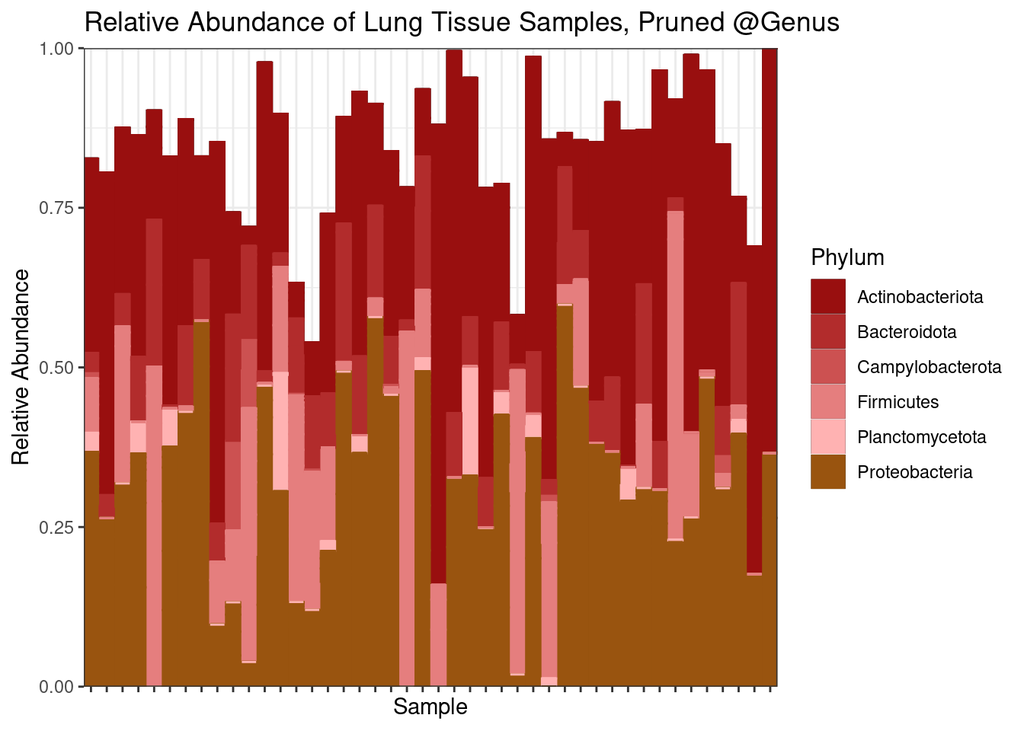

```r
plot_bar(ps_genus.prune.ts, x = "Label", fill="Phylum") +
  facet_grid(scales="free", space = "free_x") +
  geom_bar(aes(color=Phylum, fill=Phylum), stat="identity", position="stack") +
  theme_bw()  +
  coord_cartesian(ylim = c(0,1), expand=0) +
  theme(axis.text.x=element_blank()) + # not showing samples names
  labs(y="Relative Abundance", title = "Relative Abundance of Lung Tissue Samples, Pruned @Genus", x = "Sample")+
  scale_color_manual(values=SteppedSequential5Steps) +
  scale_fill_manual(values=SteppedSequential5Steps)
```

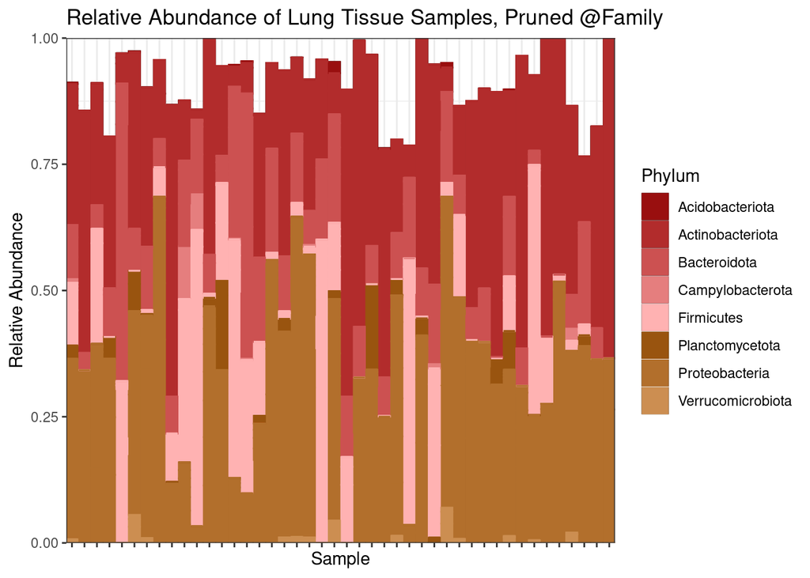

```r
plot_bar(ps_Family.prune.ts, x = "Label", fill="Phylum") +
  facet_grid(scales="free", space = "free_x") +
  geom_bar(aes(color=Phylum, fill=Phylum), stat="identity", position="stack") +
  theme_bw()  +
  coord_cartesian(ylim = c(0,1), expand=0) +
  theme(axis.text.x=element_blank()) + # not showing samples names
  labs(y="Relative Abundance", title = "Relative Abundance of Lung Tissue Samples, Pruned @Family", x = "Sample")+
  scale_color_manual(values=SteppedSequential5Steps) +
  scale_fill_manual(values=SteppedSequential5Steps)
```

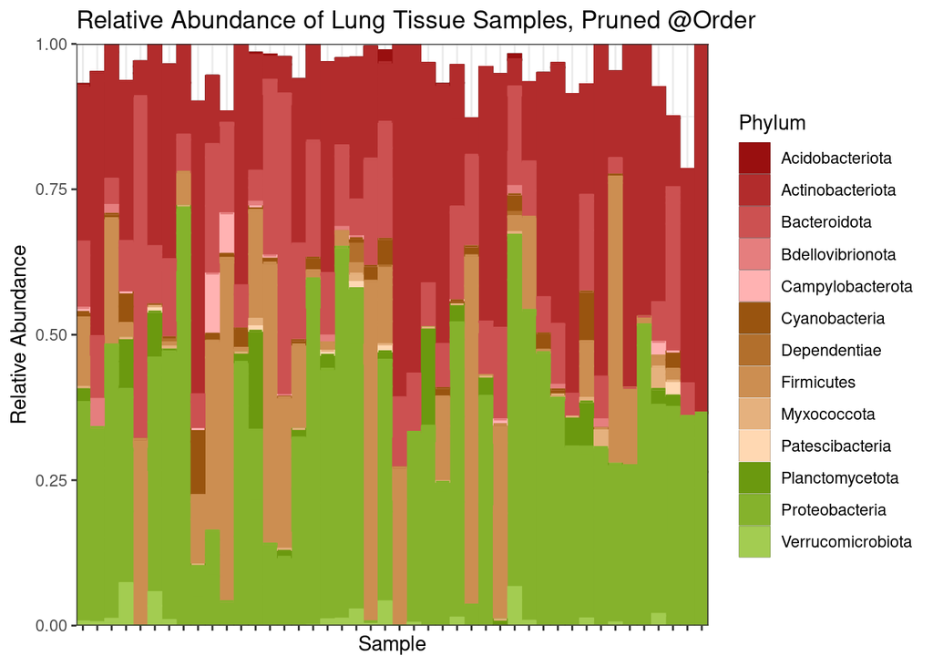

```r
plot_bar(ps_Order.prune.ts, x = "Label", fill="Phylum") +
  facet_grid(scales="free", space = "free_x") +
  geom_bar(aes(color=Phylum, fill=Phylum), stat="identity", position="stack") +
  theme_bw()  +
  coord_cartesian(ylim = c(0,1), expand=0) +
  theme(axis.text.x=element_blank()) + # not showing samples names
  labs(y="Relative Abundance", title = "Relative Abundance of Lung Tissue Samples, Pruned @Order", x = "Sample")+
  scale_color_manual(values=SteppedSequential5Steps) +
  scale_fill_manual(values=SteppedSequential5Steps)
```

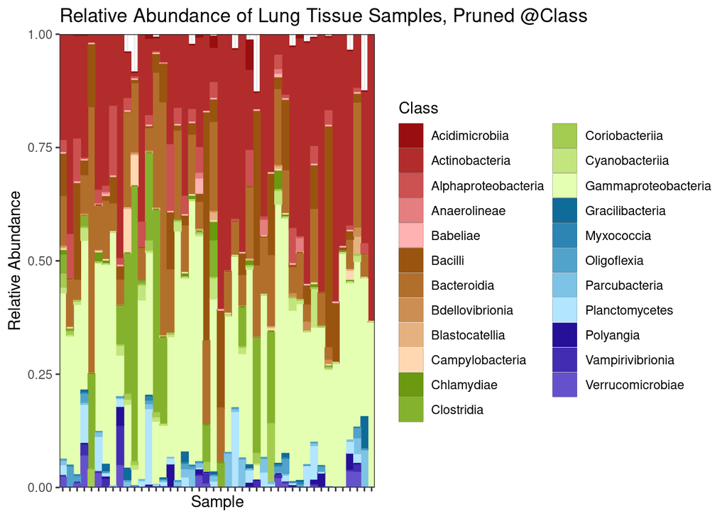

```r
plot_bar(ps_Class.prune.ts, x = "Label", fill="Class") +
  facet_grid(scales="free", space = "free_x") +
  geom_bar(aes(color=Class, fill=Class), stat="identity", position="stack") +
  theme_bw()  +
  coord_cartesian(ylim = c(0,1), expand=0) +
  theme(axis.text.x=element_blank()) + # not showing samples names
  labs(y="Relative Abundance", title = "Relative Abundance of Lung Tissue Samples, Pruned @Class", x = "Sample")+
  scale_color_manual(values=SteppedSequential5Steps) +
  scale_fill_manual(values=SteppedSequential5Steps)
```

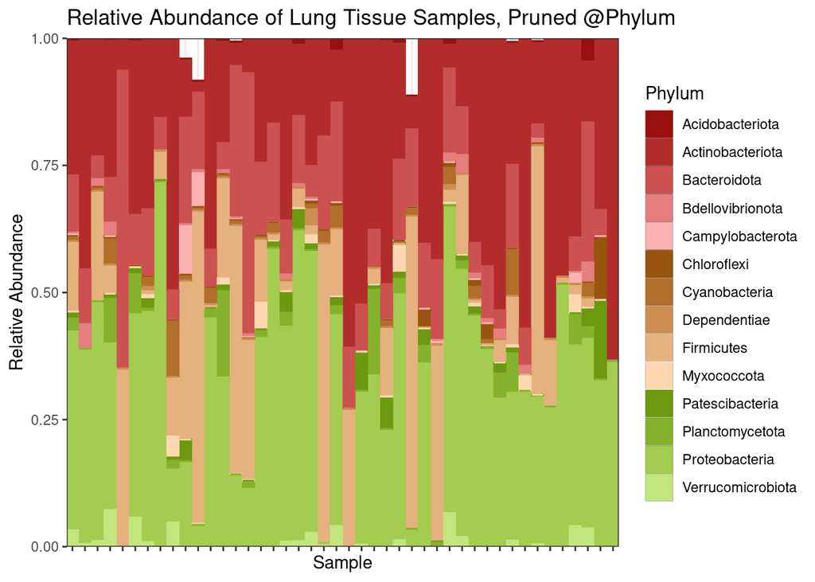

```r
plot_bar(ps_Phylum.prune.ts, x = "Label", fill="Phylum") +
  facet_grid(scales="free", space = "free_x") +
  geom_bar(aes(color=Phylum, fill=Phylum), stat="identity", position="stack") +
  theme_bw()  +
  coord_cartesian(ylim = c(0,1), expand=0) +
  theme(axis.text.x=element_blank()) + # not showing samples names
  labs(y="Relative Abundance", title = "Relative Abundance of Lung Tissue Samples, Pruned @Phylum", x = "Sample")+
  scale_color_manual(values=SteppedSequential5Steps) +
  scale_fill_manual(values=SteppedSequential5Steps)
```

## 2.3 Subset metadata

```r
meta.df %>% filter(Type == "True Sample" & Sample_type == "Lung Tissue") %>%
  filter(Label %in% phyloseq::sample_data(ps_g_notree_LT)$Label) -> meta.lt
meta.lt
```

| Label | Concentration-(ng/uL) | Sample_type | Type | Sequencing_Run | Mouse | Cage-Mouse | Genotype | Sex | Diet | Intranasal_Treatment | Surgery | Intranasal_Dose | Cohort | Cage | Week | Lung_index | Kit | DNA_ng_ul_raw | Sample_Label | Cage_Notation | Feces_weight | Orig_label | Notes | Glucose_tolerance_wk0_0m | Glucose_tolerance_wk0_10m | Glucose_tolerance_wk0_30m | Glucose_tolerance_wk0_90m | Weight_g_wk0 | Glucose_tolerance_wk10_0m | … |
| --- | --- | --- | --- | --- | --- | --- | --- | --- | --- | --- | --- | --- | --- | --- | --- | --- | --- | --- | --- | --- | --- | --- | --- | --- | --- | --- | --- | --- | --- | --- |
| JI-646 | NA | Lung Tissue | True Sample | 2 | JI-646 | 1420953-2 | WT | Male | Normal_Chow | HDM | None | 50ug/40ul | 1 | 1420953 | 10 | 9 | BT_1 | 730.0 | NA | NA | NA | NA | NA | NA | NA | NA | NA | 25.06 | NA | … |
| JI-647 | NA | Lung Tissue | True Sample | 2 | JI-647 | 1420953-4 | WT | Male | Normal_Chow | PBS | None | 40ul | 1 | 1420953 | 10 | 21 | BT_1 | 408.0 | NA | NA | NA | NA | NA | NA | NA | NA | NA | 25.34 | NA | … |
| JI-648 | NA | Lung Tissue | True Sample | 2 | JI-648 | 1420953-3 | WT | Male | Normal_Chow | PBS | None | 40ul | 1 | 1420953 | 10 | 3 | BT_1 | 446.0 | NA | NA | NA | NA | NA | NA | NA | NA | NA | 25.38 | NA | … |
| JI-649 | NA | Lung Tissue | True Sample | 2 | JI-649 | 1420953-1 | WT | Male | Normal_Chow | HDM | None | 50ug/40ul | 1 | 1420953 | 10 | 17 | BT_1 | 345.0 | NA | NA | NA | NA | NA | NA | NA | NA | NA | 25.09 | NA | … |
| JI-650 | NA | Lung Tissue | True Sample | 1 | JI-650 | 1420961-1 | WT | Female | High_Fat_Diet | HDM | None | 50ug/40ul | 1 | 1420961 | 10 | 16 | BT_1 | 403.0 | NA | NA | NA | NA | NA | NA | NA | NA | NA | 19.04 | NA | … |
| JI-651 | NA | Lung Tissue | True Sample | 2 | JI-651 | 1420958-2 | KO | Male | High_Fat_Diet | PBS | None | 40ul | 1 | 1420958 | 10 | 51 | BT_2 | 500.0 | NA | NA | NA | NA | NA | 204 | 297 | 249 | 190 | 27.40 | 231 | … |
| JI-652 | NA | Lung Tissue | True Sample | 2 | JI-652 | 1420958-1 | KO | Male | High_Fat_Diet | HDM | None | 50ug/40ul | 1 | 1420958 | 10 | 8 | BT_1 | 383.0 | NA | NA | NA | NA | NA | 216 | 312 | 296 | 187 | 24.41 | 221 | … |
| JI-653 | NA | Lung Tissue | True Sample | 2 | JI-653 | 1420950-1 | KO | Female | High_Fat_Diet | HDM | None | 50ug/40ul | 1 | 1420950 | 10 | 18 | BT_1 | 660.0 | NA | NA | NA | NA | NA | NA | NA | NA | NA | NA | NA | … |
| JI-654 | NA | Lung Tissue | True Sample | 2 | JI-654 | 1420950-2 | WT | Female | High_Fat_Diet | HDM | None | 50ug/40ul | 1 | 1420950 | 10 | 39 | BT_1 | 149.0 | NA | NA | NA | NA | NA | NA | NA | NA | NA | NA | NA | … |
| JI-655 | NA | Lung Tissue | True Sample | 2 | JI-655 | 1420951-1 | WT | Male | High_Fat_Diet | PBS | None | 40ul | 1 | 1420951 | 10 | 29 | BT_1 | 226.0 | NA | NA | NA | NA | NA | NA | NA | NA | NA | NA | NA | … |

[output cut: 34 more lines]

# 3 Lung microbiome: tests to run

Let’s see how many mice we have:

```r
meta.lt %>% filter(Diet == "High_Fat_Diet" & Week == "13") %>%
  dplyr::count(Intranasal_Treatment, Surgery) %>% arrange(n)
```

| Intranasal_Treatment | Surgery | n |
| --- | --- | --- |
| PBS | None | 1 |
| HDM | VSG | 3 |
| PBS | VSG | 3 |
| HDM | None | 4 |
| HDM | Sham | 5 |
| PBS | Sham | 7 |

```r
meta.lt %>% filter(Diet == "High_Fat_Diet" & Week == "13") %>% nrow()
```

```
## [1] 23
```

*If* we assume that the difference between none –> sham surgery groups in PBS will be the same to the difference between none –> sham surgery group in HDM, we can run the analyses of `Intranasal_Treatment + Surgery`.

Note that neither surgery nor intranasal treatment caused significant microbiome changes using UniFrac and weighted UniFrac distances.

```r
meta.lt %>% filter(Surgery == "None") %>%
  dplyr::count(Intranasal_Treatment, Diet) %>% arrange(n)
```

| Intranasal_Treatment | Diet | n |
| --- | --- | --- |
| PBS | High_Fat_Diet | 4 |
| HDM | Normal_Chow | 7 |
| PBS | Normal_Chow | 7 |
| HDM | High_Fat_Diet | 8 |

```r
meta.lt %>% filter(Surgery == "None") %>% nrow()
```

```
## [1] 26
```

Similar to above, let’s run it with `Intranasal_Treatment * Diet`.

# 4 Tools: ANCOM II and DESeq2

I propose using ANalysis of COMposition, or ANCOM-II. Here are the associated [paper](https://www.ncbi.nlm.nih.gov/pmc/articles/PMC5682008/) and the [vignette](https://bioconductor.org/packages/release/bioc/vignettes/ANCOMBC/inst/doc/ANCOM.html).

DESeq2 was built for RNA-Seq data, not amplicon sequencing, but it has been a popular tool in amplicon sequencing field. Here are the associated [vignette](https://bioconductor.org/packages/devel/bioc/vignettes/DESeq2/inst/doc/DESeq2.html) and [paper](https://genomebiology.biomedcentral.com/articles/10.1186/s13059-014-0550-8).

I do not believe ANCOM II will give results for each phylogenetic level when run at the highest resolution (ex. genus in this case). As such, ANCOM II might have to be run at **each** phylogenetic level. I will not be adjusting for multiple testing because the results should be about the same, just at different phylogenetic levels.

Note that function `ancom` refers to ANCOM II, and takes the *first* variable as main variable and the other as adjusting for.

DESeq2 is the opposite; *last* variable is main, all others are adjusting.

# 5 Q1. Hypothesis testing: Intranasal_Treatment + Surgery, all on HFD, wk 13

## 5.1 Make TSE objects

```r
ps_genus.prune %>% subset_samples(Diet == "High_Fat_Diet" & Week == "13")  %>%
  mia::makeTreeSummarizedExperimentFromPhyloseq() -> tse.LT.Q1.Genus
tse.LT.Q1.Genus
```

```
## class: TreeSummarizedExperiment
## dim: 52 23
## metadata(0):
## assays(1): counts
## rownames(52): Rhodococcus Helicobacter ... Bifidobacterium Rhodoluna
## rowData names(6): Kingdom Phylum ... Family Genus
## colnames(23): SRR29054918 SRR29054919 ... SRR29054939 SRR29054941
## colData names(42): Label Qubit_ng_ul ... Concentration..ng.uL. is.neg
## reducedDimNames(0):
## mainExpName: NULL
## altExpNames(0):
## rowLinks: NULL
## rowTree: NULL
## colLinks: NULL
## colTree: NULL
```

```r
ps_Family.prune %>% subset_samples(Diet == "High_Fat_Diet" & Week == "13")  %>%
  mia::makeTreeSummarizedExperimentFromPhyloseq() -> tse.LT.Q1.Family
tse.LT.Q1.Family
```

```
## class: TreeSummarizedExperiment
## dim: 43 23
## metadata(0):
## assays(1): counts
## rownames(43): Nocardiaceae Ruminococcaceae ... Bifidobacteriaceae
##   Microbacteriaceae
## rowData names(6): Kingdom Phylum ... Family Genus
## colnames(23): SRR29054918 SRR29054919 ... SRR29054939 SRR29054941
## colData names(42): Label Qubit_ng_ul ... Concentration..ng.uL. is.neg
## reducedDimNames(0):
## mainExpName: NULL
## altExpNames(0):
## rowLinks: NULL
## rowTree: NULL
## colLinks: NULL
## colTree: NULL
```

```r
ps_Order.prune %>% subset_samples(Diet == "High_Fat_Diet" & Week == "13")  %>%
  mia::makeTreeSummarizedExperimentFromPhyloseq() -> tse.LT.Q1.Order
tse.LT.Q1.Order
```

```
## class: TreeSummarizedExperiment
## dim: 39 23
## metadata(0):
## assays(1): counts
## rownames(39): Corynebacteriales Chlamydiales ... Micrococcales
##   Bifidobacteriales
## rowData names(6): Kingdom Phylum ... Family Genus
## colnames(23): SRR29054918 SRR29054919 ... SRR29054939 SRR29054941
## colData names(42): Label Qubit_ng_ul ... Concentration..ng.uL. is.neg
## reducedDimNames(0):
## mainExpName: NULL
## altExpNames(0):
## rowLinks: NULL
## rowTree: NULL
## colLinks: NULL
## colTree: NULL
```

```r
ps_Class.prune %>% subset_samples(Diet == "High_Fat_Diet" & Week == "13")  %>%
  mia::makeTreeSummarizedExperimentFromPhyloseq() -> tse.LT.Q1.Class
tse.LT.Q1.Class
```

```
## class: TreeSummarizedExperiment
## dim: 23 23
## metadata(0):
## assays(1): counts
## rownames(23): Actinobacteria Chlamydiae ... Bacilli Acidimicrobiia
## rowData names(6): Kingdom Phylum ... Family Genus
## colnames(23): SRR29054918 SRR29054919 ... SRR29054939 SRR29054941
## colData names(42): Label Qubit_ng_ul ... Concentration..ng.uL. is.neg
## reducedDimNames(0):
## mainExpName: NULL
## altExpNames(0):
## rowLinks: NULL
## rowTree: NULL
## colLinks: NULL
## colTree: NULL
```

```r
ps_Phylum.prune %>% subset_samples(Diet == "High_Fat_Diet" & Week == "13")  %>%
  mia::makeTreeSummarizedExperimentFromPhyloseq() -> tse.LT.Q1.Phylum
tse.LT.Q1.Phylum
```

```
## class: TreeSummarizedExperiment
## dim: 14 23
## metadata(0):
## assays(1): counts
## rownames(14): Actinobacteriota Verrucomicrobiota ... Patescibacteria
##   Firmicutes
## rowData names(6): Kingdom Phylum ... Family Genus
## colnames(23): SRR29054918 SRR29054919 ... SRR29054939 SRR29054941
## colData names(42): Label Qubit_ng_ul ... Concentration..ng.uL. is.neg
## reducedDimNames(0):
## mainExpName: NULL
## altExpNames(0):
## rowLinks: NULL
## rowTree: NULL
## colLinks: NULL
## colTree: NULL
```

## 5.2 ANCOM II

### 5.2.1 Genus

```r
set.seed(123) # Set seed for reproducibility
n_cl_requested = 24

# Genus level
LT.Q1.Genus <- ANCOMBC::ancom(data=tse.LT.Q1.Genus, assay_name="counts", tax_level="Genus",
                               p_adj_method="holm", prv_cut=0, lib_cut=0,
                               main_var="Intranasal_Treatment", adj_formula="Surgery",
                               alpha = 0.05, struc_zero=TRUE,
                               n_cl = n_cl_requested)
```

```
## 'ancom' has been fully evolved to 'ancombc2'.
## Explore the enhanced capabilities of our refined method!
```

```r
res.LT.Q1.Genus = LT.Q1.Genus$res
res.LT.Q1.Genus %>% filter(detected_0.7 == TRUE) -> tab.LT.Q1.Genus.sig
tab.LT.Q1.Genus.sig
```

| taxon | W | detected_0.9 | detected_0.8 | detected_0.7 | detected_0.6 |
| --- | --- | --- | --- | --- | --- |
| Helicobacter | Inf | TRUE | TRUE | TRUE | TRUE |
| Colidextribacter | Inf | TRUE | TRUE | TRUE | TRUE |
| Oscillibacter | Inf | TRUE | TRUE | TRUE | TRUE |
| Roseburia | Inf | TRUE | TRUE | TRUE | TRUE |
| Tyzzerella | Inf | TRUE | TRUE | TRUE | TRUE |
| Muribaculum | Inf | TRUE | TRUE | TRUE | TRUE |
| Alistipes | Inf | TRUE | TRUE | TRUE | TRUE |
| Enterorhabdus | Inf | TRUE | TRUE | TRUE | TRUE |
| Acetatifactor | Inf | TRUE | TRUE | TRUE | TRUE |
| GCA-900066575 | Inf | TRUE | TRUE | TRUE | TRUE |

[output cut: 8 more lines]

Since this is based on structural zeroes, switching the order will yield different results.

### 5.2.2 Family

```r
# Family level
LT.Q1.Family <- ANCOMBC::ancom(data=tse.LT.Q1.Family, assay_name="counts", tax_level="Family",
                               p_adj_method="holm", prv_cut=0, lib_cut=0,
                               main_var="Intranasal_Treatment", adj_formula="Surgery",
                               alpha = 0.05, struc_zero=TRUE,
                               n_cl = n_cl_requested)
```

```
## 'ancom' has been fully evolved to 'ancombc2'.
## Explore the enhanced capabilities of our refined method!
```

```r
res.LT.Q1.Family = LT.Q1.Family$res
res.LT.Q1.Family %>% filter(detected_0.7 == TRUE)  -> tab.LT.Q1.Family.sig
tab.LT.Q1.Family.sig
```

| taxon | W | detected_0.9 | detected_0.8 | detected_0.7 | detected_0.6 |
| --- | --- | --- | --- | --- | --- |
| Ruminococcaceae | Inf | TRUE | TRUE | TRUE | TRUE |
| Parachlamydiaceae | Inf | TRUE | TRUE | TRUE | TRUE |
| Helicobacteraceae | Inf | TRUE | TRUE | TRUE | TRUE |
| Rikenellaceae | Inf | TRUE | TRUE | TRUE | TRUE |
| Eggerthellaceae | Inf | TRUE | TRUE | TRUE | TRUE |
| Rubinisphaeraceae | Inf | TRUE | TRUE | TRUE | TRUE |
| Methylophilaceae | Inf | TRUE | TRUE | TRUE | TRUE |
| Xanthomonadaceae | Inf | TRUE | TRUE | TRUE | TRUE |
| Bifidobacteriaceae | Inf | TRUE | TRUE | TRUE | TRUE |

Still all structural zeroes.

### 5.2.3 Order

```r
set.seed(123) # Set seed for reproducibility

# Order level
LT.Q1.Order <- ANCOMBC::ancom(data=tse.LT.Q1.Order, assay_name="counts", tax_level="Order",
                               p_adj_method="holm", prv_cut=0,  lib_cut=0,
                               main_var="Intranasal_Treatment", adj_formula="Surgery",
                               alpha = 0.05, struc_zero=TRUE,
                               n_cl = n_cl_requested)
```

```
## 'ancom' has been fully evolved to 'ancombc2'.
## Explore the enhanced capabilities of our refined method!
```

```r
res.LT.Q1.Order = LT.Q1.Order$res
res.LT.Q1.Order %>% filter(detected_0.7 == TRUE) -> tab.LT.Q1.Order.sig
tab.LT.Q1.Order.sig
```

| taxon | W | detected_0.9 | detected_0.8 | detected_0.7 | detected_0.6 |
| --- | --- | --- | --- | --- | --- |
| Campylobacterales | Inf | TRUE | TRUE | TRUE | TRUE |
| Polyangiales | Inf | TRUE | TRUE | TRUE | TRUE |
| Peptostreptococcales-Tissierellales | Inf | TRUE | TRUE | TRUE | TRUE |
| Microtrichales | Inf | TRUE | TRUE | TRUE | TRUE |
| Bifidobacteriales | Inf | TRUE | TRUE | TRUE | TRUE |

### 5.2.4 Class

```r
set.seed(123) # Set seed for reproducibility

# Class level
LT.Q1.Class <- ANCOMBC::ancom(data=tse.LT.Q1.Class, assay_name="counts", tax_level="Class",
                               p_adj_method="holm", prv_cut=0, lib_cut=0,
                               main_var="Intranasal_Treatment", adj_formula="Surgery",
                               alpha = 0.05, struc_zero=TRUE,
                               n_cl = n_cl_requested)
```

```
## 'ancom' has been fully evolved to 'ancombc2'.
## Explore the enhanced capabilities of our refined method!
```

```r
res.LT.Q1.Class = LT.Q1.Class$res
res.LT.Q1.Class %>% filter(detected_0.7 == TRUE) -> tab.LT.Q1.Class.sig
tab.LT.Q1.Class.sig
```

| taxon | W | detected_0.9 | detected_0.8 | detected_0.7 | detected_0.6 |
| --- | --- | --- | --- | --- | --- |
| Campylobacteria | Inf | TRUE | TRUE | TRUE | TRUE |
| Acidimicrobiia | Inf | TRUE | TRUE | TRUE | TRUE |

### 5.2.5 Phylum

```r
set.seed(123) # Set seed for reproducibility

# Phylum level
LT.Q1.Phylum <- ANCOMBC::ancom(data=tse.LT.Q1.Phylum, assay_name="counts", tax_level="Phylum",
                               p_adj_method="holm", prv_cut=0, lib_cut=0,
                               main_var="Intranasal_Treatment", adj_formula="Surgery",
                               alpha = 0.05, struc_zero=TRUE,
                               n_cl = n_cl_requested)
```

```
## 'ancom' has been fully evolved to 'ancombc2'.
## Explore the enhanced capabilities of our refined method!
```

```r
res.LT.Q1.Phylum = LT.Q1.Phylum$res
res.LT.Q1.Phylum %>% filter(detected_0.7 == TRUE)  -> tab.LT.Q1.Phylum.sig
tab.LT.Q1.Phylum.sig
```

| taxon | W | detected_0.9 | detected_0.8 | detected_0.7 | detected_0.6 |
| --- | --- | --- | --- | --- | --- |
| Campylobacterota | Inf | TRUE | TRUE | TRUE | TRUE |

### 5.2.6 Aggregate Results

```r
tab.LT.Q1.Genus.sig$Tax_rank <- "Genus"
tab.LT.Q1.Family.sig$Tax_rank <- "Family"
tab.LT.Q1.Order.sig$Tax_rank <- "Order"
tab.LT.Q1.Class.sig$Tax_rank <- "Class"
tab.LT.Q1.Phylum.sig$Tax_rank <- "Phylum"

rbind(tab.LT.Q1.Genus.sig,
      tab.LT.Q1.Family.sig,
      tab.LT.Q1.Order.sig,
      tab.LT.Q1.Class.sig,
      tab.LT.Q1.Phylum.sig) -> tab.LT.Q1

tab.LT.Q1$Test <- "ANCOM II, Lung Tissue: all HFD, wk 13, intranasal treatment + surgery. Structural zeroes from intranasal treatment"

tab.LT.Q1
```

| taxon | W | detected_0.9 | detected_0.8 | detected_0.7 | detected_0.6 | Tax_rank | Test |
| --- | --- | --- | --- | --- | --- | --- | --- |
| Helicobacter | Inf | TRUE | TRUE | TRUE | TRUE | Genus | ANCOM II, Lung Tissue: all HFD, wk 13, intranasal treatment + surgery. Structural zeroes from intranasal treatment |
| Colidextribacter | Inf | TRUE | TRUE | TRUE | TRUE | Genus | ANCOM II, Lung Tissue: all HFD, wk 13, intranasal treatment + surgery. Structural zeroes from intranasal treatment |
| Oscillibacter | Inf | TRUE | TRUE | TRUE | TRUE | Genus | ANCOM II, Lung Tissue: all HFD, wk 13, intranasal treatment + surgery. Structural zeroes from intranasal treatment |
| Roseburia | Inf | TRUE | TRUE | TRUE | TRUE | Genus | ANCOM II, Lung Tissue: all HFD, wk 13, intranasal treatment + surgery. Structural zeroes from intranasal treatment |
| Tyzzerella | Inf | TRUE | TRUE | TRUE | TRUE | Genus | ANCOM II, Lung Tissue: all HFD, wk 13, intranasal treatment + surgery. Structural zeroes from intranasal treatment |
| Muribaculum | Inf | TRUE | TRUE | TRUE | TRUE | Genus | ANCOM II, Lung Tissue: all HFD, wk 13, intranasal treatment + surgery. Structural zeroes from intranasal treatment |
| Alistipes | Inf | TRUE | TRUE | TRUE | TRUE | Genus | ANCOM II, Lung Tissue: all HFD, wk 13, intranasal treatment + surgery. Structural zeroes from intranasal treatment |
| Enterorhabdus | Inf | TRUE | TRUE | TRUE | TRUE | Genus | ANCOM II, Lung Tissue: all HFD, wk 13, intranasal treatment + surgery. Structural zeroes from intranasal treatment |
| Acetatifactor | Inf | TRUE | TRUE | TRUE | TRUE | Genus | ANCOM II, Lung Tissue: all HFD, wk 13, intranasal treatment + surgery. Structural zeroes from intranasal treatment |
| GCA-900066575 | Inf | TRUE | TRUE | TRUE | TRUE | Genus | ANCOM II, Lung Tissue: all HFD, wk 13, intranasal treatment + surgery. Structural zeroes from intranasal treatment |

[output cut: 25 more lines]

Note that ALL of them are structural zeroes.

## 5.3 DESeq2

### 5.3.1 Genus

```r
ds.LT.Q1_Genus <- DESeq2::DESeqDataSet(tse.LT.Q1.Genus, ~ Intranasal_Treatment + Surgery)
dds.LT.Q1_Genus <- DESeq2::DESeq(ds.LT.Q1_Genus)
```

```
## -- note: fitType='parametric', but the dispersion trend was not well captured by the
##    function: y = a/x + b, and a local regression fit was automatically substituted.
##    specify fitType='local' or 'mean' to avoid this message next time.
```

```
## -- replacing outliers and refitting for 25 genes
## -- DESeq argument 'minReplicatesForReplace' = 7
## -- original counts are preserved in counts(dds)
```

```r
DESeq2::summary(dds.LT.Q1_Genus)
```

```
## $samples
## # A tibble: 1 × 6
##   total_counts min_counts max_counts median_counts mean_counts stdev_counts
##          <dbl>      <dbl>      <dbl>         <dbl>       <dbl>        <dbl>
## 1       324551       1352      37772         12322      14111.       10424.
##
## $features
## # A tibble: 1 × 3
##   total singletons per_sample_avg
##   <int>      <int>          <dbl>
## 1    52          0           10.2
```

```r
resultsNames(dds.LT.Q1_Genus)
```

```
## [1] "Intercept"                       "Intranasal_Treatment_HDM_vs_PBS"
## [3] "Surgery_Sham_vs_None"            "Surgery_VSG_vs_None"
```

```r
results(dds.LT.Q1_Genus, tidy = TRUE, contrast = c("Intranasal_Treatment", "HDM", "PBS")) %>% # tidy converts to df
  filter(padj < 0.05) -> LT.Q1.Genus.Res
LT.Q1.Genus.Res$Comparison <- c("Intranasal Treatment: HDM over PBS")

results(dds.LT.Q1_Genus, contrast = c("Surgery", "Sham", "None"), tidy = TRUE) %>%
  filter(padj < 0.05) -> tmp
tmp$Comparison <- c("Surgery: Sham over None")
rbind(tmp, LT.Q1.Genus.Res) -> LT.Q1.Genus.Res

results(dds.LT.Q1_Genus, contrast = c("Surgery", "VSG", "None"), tidy = TRUE) %>%
  filter(padj < 0.05) -> tmp
tmp$Comparison <- c("Surgery: VSG over None")
rbind(tmp, LT.Q1.Genus.Res) -> LT.Q1.Genus.Res

LT.Q1.Genus.Res$Compare_taxon <- "Genus"

LT.Q1.Genus.Res
```

| row | baseMean | log2FoldChange | lfcSE | stat | pvalue | padj | Comparison | Compare_taxon |
| --- | --- | --- | --- | --- | --- | --- | --- | --- |
| Pseudarcicella | 178.063082 | -30.000000 | 4.372224 | -6.861497 | 6.814273e-12 | 5.288550e-11 | Surgery: VSG over None | Genus |
| Legionella | 179.368632 | -21.784796 | 3.962783 | -5.497347 | 3.855472e-08 | 1.301222e-07 | Surgery: VSG over None | Genus |
| Burkholderia-Caballeronia-Paraburkholderia | 135.771001 | 21.210814 | 4.385961 | 4.836070 | 1.324316e-06 | 3.972948e-06 | Surgery: VSG over None | Genus |
| Chitinivorax | 15.270936 | -30.000000 | 4.372887 | -6.860456 | 6.864126e-12 | 5.288550e-11 | Surgery: VSG over None | Genus |
| Polynucleobacter | 1.532693 | -21.227565 | 4.440498 | -4.780447 | 1.749057e-06 | 4.293139e-06 | Surgery: VSG over None | Genus |
| Duganella | 42.670976 | -25.761655 | 4.399570 | -5.855493 | 4.755965e-09 | 2.140184e-08 | Surgery: VSG over None | Genus |
| Paucibacter | 254.293015 | -17.445524 | 3.133859 | -5.566787 | 2.594789e-08 | 1.000847e-07 | Surgery: VSG over None | Genus |
| Acidovorax | 18.238222 | -30.000000 | 4.372794 | -6.860603 | 6.857055e-12 | 5.288550e-11 | Surgery: VSG over None | Genus |
| Rhodoferax | 83.228838 | -15.147233 | 4.344400 | -3.486611 | 4.891823e-04 | 1.100660e-03 | Surgery: VSG over None | Genus |
| Bacillus | 161.816389 | -17.889599 | 3.733887 | -4.791147 | 1.658307e-06 | 4.293139e-06 | Surgery: VSG over None | Genus |

[output cut: 30 more lines]

### 5.3.2 Family

```r
ds.LT.Q1_Family <- DESeq2::DESeqDataSet(tse.LT.Q1.Family, ~ Intranasal_Treatment + Surgery)
dds.LT.Q1_Family <- DESeq2::DESeq(ds.LT.Q1_Family)
```

```
## -- note: fitType='parametric', but the dispersion trend was not well captured by the
##    function: y = a/x + b, and a local regression fit was automatically substituted.
##    specify fitType='local' or 'mean' to avoid this message next time.
```

```
## -- replacing outliers and refitting for 23 genes
## -- DESeq argument 'minReplicatesForReplace' = 7
## -- original counts are preserved in counts(dds)
```

```r
results(dds.LT.Q1_Family, tidy = TRUE, contrast = c("Intranasal_Treatment", "HDM", "PBS")) %>% # tidy converts to df
  filter(padj < 0.05) -> LT.Q1.Family.Res
LT.Q1.Family.Res$Comparison <- c("Intranasal Treatment: HDM over PBS")

results(dds.LT.Q1_Family, contrast = c("Surgery", "Sham", "None"), tidy = TRUE) %>%
  filter(padj < 0.05) -> tmp
tmp$Comparison <- c("Surgery: Sham over None")
rbind(tmp, LT.Q1.Family.Res) -> LT.Q1.Family.Res

results(dds.LT.Q1_Family, contrast = c("Surgery", "VSG", "None"), tidy = TRUE) %>%
  filter(padj < 0.05) -> tmp
tmp$Comparison <- c("Surgery: VSG over None")
rbind(tmp, LT.Q1.Family.Res) -> LT.Q1.Family.Res

LT.Q1.Family.Res$Compare_taxon <- "Family"

LT.Q1.Family.Res
```

| row | baseMean | log2FoldChange | lfcSE | stat | pvalue | padj | Comparison | Compare_taxon |
| --- | --- | --- | --- | --- | --- | --- | --- | --- |
| Chlamydiaceae | 163.95208 | -16.035521 | 4.344554 | -3.690947 | 2.234203e-04 | 1.172956e-03 | Surgery: VSG over None | Family |
| Spirosomaceae | 264.89529 | -30.000000 | 3.857703 | -7.776649 | 7.447098e-15 | 1.563891e-13 | Surgery: VSG over None | Family |
| Legionellaceae | 179.44717 | -21.796539 | 3.987393 | -5.466364 | 4.593613e-08 | 3.215529e-07 | Surgery: VSG over None | Family |
| Chitinimonadaceae | 15.29864 | -30.000000 | 4.372887 | -6.860456 | 6.864104e-12 | 7.207309e-11 | Surgery: VSG over None | Family |
| Comamonadaceae | 993.81145 | -4.645543 | 1.857682 | -2.500720 | 1.239410e-02 | 3.718229e-02 | Surgery: VSG over None | Family |
| Beijerinckiaceae | 90.57564 | -15.359739 | 4.271764 | -3.595644 | 3.235905e-04 | 1.359080e-03 | Surgery: VSG over None | Family |
| Sphingomonadaceae | 88.24501 | -14.012303 | 4.344208 | -3.225514 | 1.257468e-03 | 4.401138e-03 | Surgery: VSG over None | Family |
| Chlamydiaceae | 163.95208 | -14.427838 | 3.906103 | -3.693666 | 2.210441e-04 | 7.736543e-04 | Surgery: Sham over None | Family |
| Spirosomaceae | 264.89529 | -14.685815 | 3.440529 | -4.268476 | 1.968132e-05 | 8.266154e-05 | Surgery: Sham over None | Family |
| Rubinisphaeraceae | 64.91980 | 21.262487 | 4.015690 | 5.294853 | 1.191124e-07 | 2.501360e-06 | Surgery: Sham over None | Family |

[output cut: 12 more lines]

### 5.3.3 Order

```r
ds.LT.Q1_Order <- DESeq2::DESeqDataSet(tse.LT.Q1.Order, ~ Intranasal_Treatment + Surgery)
dds.LT.Q1_Order <- DESeq2::DESeq(ds.LT.Q1_Order)
```

```
## -- note: fitType='parametric', but the dispersion trend was not well captured by the
##    function: y = a/x + b, and a local regression fit was automatically substituted.
##    specify fitType='local' or 'mean' to avoid this message next time.
```

```
## -- replacing outliers and refitting for 21 genes
## -- DESeq argument 'minReplicatesForReplace' = 7
## -- original counts are preserved in counts(dds)
```

```r
results(dds.LT.Q1_Order, tidy = TRUE, contrast = c("Intranasal_Treatment", "HDM", "PBS")) %>% # tidy converts to df
  filter(padj < 0.05) -> LT.Q1.Order.Res
LT.Q1.Order.Res$Comparison <- c("Intranasal Treatment: HDM over PBS")

results(dds.LT.Q1_Order, contrast = c("Surgery", "Sham", "None"), tidy = TRUE) %>%
  filter(padj < 0.05) -> tmp
tmp$Comparison <- c("Surgery: Sham over None")
rbind(tmp, LT.Q1.Order.Res) -> LT.Q1.Order.Res

results(dds.LT.Q1_Order, contrast = c("Surgery", "VSG", "None"), tidy = TRUE) %>%
  filter(padj < 0.05) -> tmp
tmp$Comparison <- c("Surgery: VSG over None")
rbind(tmp, LT.Q1.Order.Res) -> LT.Q1.Order.Res

LT.Q1.Order.Res$Compare_taxon <- "Order"

LT.Q1.Order.Res
```

| row | baseMean | log2FoldChange | lfcSE | stat | pvalue | padj | Comparison | Compare_taxon |
| --- | --- | --- | --- | --- | --- | --- | --- | --- |
| Planctomycetales | 74.848625 | -13.50988 | 4.406680 | -3.065772 | 2.171086e-03 | 7.598799e-03 | Surgery: VSG over None | Order |
| Legionellales | 179.715255 | -21.72272 | 3.880697 | -5.597633 | 2.172979e-08 | 2.281628e-07 | Surgery: VSG over None | Order |
| Sphingomonadales | 88.430131 | -14.00501 | 4.327305 | -3.236427 | 1.210362e-03 | 5.083519e-03 | Surgery: VSG over None | Order |
| Polyangiales | 8.806466 | -23.50111 | 4.438959 | -5.294285 | 1.194831e-07 | 8.363819e-07 | Surgery: VSG over None | Order |
| 0319-6G20 | 54.151162 | -25.15683 | 4.370264 | -5.756365 | 8.594423e-09 | 1.804829e-07 | Surgery: VSG over None | Order |
| Candidatus Nomurabacteria | 72.547069 | -20.97266 | 4.411438 | -4.754154 | 1.992790e-06 | 1.046215e-05 | Surgery: VSG over None | Order |
| Cytophagales | 276.932589 | -10.68485 | 3.600170 | -2.967873 | 2.998683e-03 | 2.099078e-02 | Surgery: Sham over None | Order |
| Legionellales | 179.715255 | -16.18215 | 3.475843 | -4.655604 | 3.230319e-06 | 6.783671e-05 | Surgery: Sham over None | Order |
| Sphingomonadales | 88.430131 | -16.74018 | 3.891016 | -4.302264 | 1.690620e-05 | 1.775151e-04 | Surgery: Sham over None | Order |
| Cytophagales | 276.932589 | -10.38828 | 2.836716 | -3.662079 | 2.501768e-04 | 7.505305e-04 | Intranasal Treatment: HDM over PBS | Order |

[output cut: 6 more lines]

### 5.3.4 Class

```r
ds.LT.Q1_Class <- DESeq2::DESeqDataSet(tse.LT.Q1.Class, ~ Intranasal_Treatment + Surgery)
dds.LT.Q1_Class <- DESeq2::DESeq(ds.LT.Q1_Class)
```

```
## -- note: fitType='parametric', but the dispersion trend was not well captured by the
##    function: y = a/x + b, and a local regression fit was automatically substituted.
##    specify fitType='local' or 'mean' to avoid this message next time.
```

```
## -- replacing outliers and refitting for 9 genes
## -- DESeq argument 'minReplicatesForReplace' = 7
## -- original counts are preserved in counts(dds)
```

```r
results(dds.LT.Q1_Class, tidy = TRUE, contrast = c("Intranasal_Treatment", "HDM", "PBS")) %>% # tidy converts to df
  filter(padj < 0.05) -> LT.Q1.Class.Res
LT.Q1.Class.Res$Comparison <- c("Intranasal Treatment: HDM over PBS")

results(dds.LT.Q1_Class, contrast = c("Surgery", "Sham", "None"), tidy = TRUE) %>%
  filter(padj < 0.05) -> tmp
tmp$Comparison <- c("Surgery: Sham over None")
rbind(tmp, LT.Q1.Class.Res) -> LT.Q1.Class.Res

results(dds.LT.Q1_Class, contrast = c("Surgery", "VSG", "None"), tidy = TRUE) %>%
  filter(padj < 0.05) -> tmp
tmp$Comparison <- c("Surgery: VSG over None")
rbind(tmp, LT.Q1.Class.Res) -> LT.Q1.Class.Res

LT.Q1.Class.Res$Compare_taxon <- "Class"

LT.Q1.Class.Res
```

| row | baseMean | log2FoldChange | lfcSE | stat | pvalue | padj | Comparison | Compare_taxon |
| --- | --- | --- | --- | --- | --- | --- | --- | --- |
| Blastocatellia | 111.54018 | -30.000000 | 4.372355 | -6.861292 | 6.824070e-12 | 1.091851e-10 | Surgery: VSG over None | Class |
| Verrucomicrobiae | 154.90811 | -27.164445 | 4.369499 | -6.216833 | 5.072898e-10 | 4.058318e-09 | Surgery: VSG over None | Class |
| Blastocatellia | 111.54018 | -13.720884 | 3.908357 | -3.510652 | 4.470087e-04 | 7.152140e-03 | Surgery: Sham over None | Class |
| Gammaproteobacteria | 6241.14957 | -2.794471 | 1.008004 | -2.772282 | 5.566487e-03 | 2.968793e-02 | Surgery: Sham over None | Class |
| Cyanobacteriia | 218.26211 | -10.007455 | 3.060968 | -3.269376 | 1.077850e-03 | 8.622802e-03 | Surgery: Sham over None | Class |
| Blastocatellia | 111.54018 | -14.755821 | 3.108064 | -4.747592 | 2.058528e-06 | 1.646822e-05 | Intranasal Treatment: HDM over PBS | Class |
| Polyangia | 61.47354 | -8.365868 | 3.064833 | -2.729632 | 6.340497e-03 | 2.536199e-02 | Intranasal Treatment: HDM over PBS | Class |
| Cyanobacteriia | 218.26211 | -9.128335 | 2.409572 | -3.788364 | 1.516429e-04 | 8.087619e-04 | Intranasal Treatment: HDM over PBS | Class |
| Acidimicrobiia | 54.80458 | -26.056107 | 3.098190 | -8.410107 | 4.096378e-17 | 6.554205e-16 | Intranasal Treatment: HDM over PBS | Class |

### 5.3.5 Phylum

```r
ds.LT.Q1_Phylum <- DESeq2::DESeqDataSet(tse.LT.Q1.Phylum, ~ Intranasal_Treatment + Surgery)
dds.LT.Q1_Phylum <- DESeq2::DESeq(ds.LT.Q1_Phylum)
```

```
## -- note: fitType='parametric', but the dispersion trend was not well captured by the
##    function: y = a/x + b, and a local regression fit was automatically substituted.
##    specify fitType='local' or 'mean' to avoid this message next time.
```

```
## -- replacing outliers and refitting for 2 genes
## -- DESeq argument 'minReplicatesForReplace' = 7
## -- original counts are preserved in counts(dds)
```

```r
results(dds.LT.Q1_Phylum, tidy = TRUE, contrast = c("Intranasal_Treatment", "HDM", "PBS")) %>% # tidy converts to df
  filter(padj < 0.05) -> LT.Q1.Phylum.Res
LT.Q1.Phylum.Res$Comparison <- c("Intranasal_Treatment", "HDM", "PBS")

results(dds.LT.Q1_Phylum, contrast = c("Surgery", "Sham", "None"), tidy = TRUE) %>%
  filter(padj < 0.05) -> tmp
tmp$Comparison <- c("Surgery: Sham over None")
rbind(tmp, LT.Q1.Phylum.Res) -> LT.Q1.Phylum.Res

results(dds.LT.Q1_Phylum, contrast = c("Surgery", "VSG", "None"), tidy = TRUE) %>%
  filter(padj < 0.05)  -> tmp
tmp$Comparison <- c("Surgery: VSG over None")
rbind(tmp, LT.Q1.Phylum.Res) -> LT.Q1.Phylum.Res

LT.Q1.Phylum.Res$Compare_taxon <- "Phylum"

LT.Q1.Phylum.Res
```

| row | baseMean | log2FoldChange | lfcSE | stat | pvalue | padj | Comparison | Compare_taxon |
| --- | --- | --- | --- | --- | --- | --- | --- | --- |
| Acidobacteriota | 122.028371 | -17.580587 | 4.311432 | -4.077668 | 4.548969e-05 | 5.913659e-04 | Surgery: VSG over None | Phylum |
| Campylobacterota | 2.119605 | -23.968702 | 3.989196 | -6.008404 | 1.873587e-09 | 2.435663e-08 | Surgery: Sham over None | Phylum |
| Acidobacteriota | 122.028371 | -14.675433 | 3.875322 | -3.786893 | 1.525425e-04 | 9.915263e-04 | Surgery: Sham over None | Phylum |
| Proteobacteria | 6716.571323 | -2.741359 | 1.022412 | -2.681266 | 7.334411e-03 | 3.178245e-02 | Surgery: Sham over None | Phylum |
| Myxococcota | 109.319848 | -7.877013 | 3.152811 | -2.498409 | 1.247521e-02 | 4.054442e-02 | Surgery: Sham over None | Phylum |
| Campylobacterota | 2.119605 | -23.056861 | 3.134509 | -7.355812 | 1.897701e-13 | 2.467011e-12 | Intranasal_Treatment | Phylum |
| Acidobacteriota | 122.028371 | -15.152750 | 3.067319 | -4.940064 | 7.809705e-07 | 5.076308e-06 | HDM | Phylum |
| Myxococcota | 109.319848 | -8.505303 | 2.482276 | -3.426413 | 6.116090e-04 | 2.650306e-03 | PBS | Phylum |

### 5.3.6 Aggregate results

```r
rbind(LT.Q1.Genus.Res,
      LT.Q1.Family.Res,
      LT.Q1.Class.Res,
      LT.Q1.Order.Res,
      LT.Q1.Phylum.Res) -> LT.Q1.deseq

LT.Q1.deseq$Test <- "DESeq2, Lung Tissue: all HFD, wk 13, intranasal treatment + surgery"
```

```r
tab.LT.Q1 %>% filter(taxon %in% LT.Q1.deseq$row) -> ancom.intersect
ancom.intersect
```

| taxon | W | detected_0.9 | detected_0.8 | detected_0.7 | detected_0.6 | Tax_rank | Test |
| --- | --- | --- | --- | --- | --- | --- | --- |
| SH-PL14 | Inf | TRUE | TRUE | TRUE | TRUE | Genus | ANCOM II, Lung Tissue: all HFD, wk 13, intranasal treatment + surgery. Structural zeroes from intranasal treatment |
| Polynucleobacter | Inf | TRUE | TRUE | TRUE | TRUE | Genus | ANCOM II, Lung Tissue: all HFD, wk 13, intranasal treatment + surgery. Structural zeroes from intranasal treatment |
| Duganella | Inf | TRUE | TRUE | TRUE | TRUE | Genus | ANCOM II, Lung Tissue: all HFD, wk 13, intranasal treatment + surgery. Structural zeroes from intranasal treatment |
| Rubinisphaeraceae | Inf | TRUE | TRUE | TRUE | TRUE | Family | ANCOM II, Lung Tissue: all HFD, wk 13, intranasal treatment + surgery. Structural zeroes from intranasal treatment |
| Polyangiales | Inf | TRUE | TRUE | TRUE | TRUE | Order | ANCOM II, Lung Tissue: all HFD, wk 13, intranasal treatment + surgery. Structural zeroes from intranasal treatment |
| Peptostreptococcales-Tissierellales | Inf | TRUE | TRUE | TRUE | TRUE | Order | ANCOM II, Lung Tissue: all HFD, wk 13, intranasal treatment + surgery. Structural zeroes from intranasal treatment |
| Acidimicrobiia | Inf | TRUE | TRUE | TRUE | TRUE | Class | ANCOM II, Lung Tissue: all HFD, wk 13, intranasal treatment + surgery. Structural zeroes from intranasal treatment |
| Campylobacterota | Inf | TRUE | TRUE | TRUE | TRUE | Phylum | ANCOM II, Lung Tissue: all HFD, wk 13, intranasal treatment + surgery. Structural zeroes from intranasal treatment |

```r
LT.Q1.deseq %>% filter(row %in% tab.LT.Q1$taxon)
```

| row | baseMean | log2FoldChange | lfcSE | stat | pvalue | padj | Comparison | Compare_taxon | Test |
| --- | --- | --- | --- | --- | --- | --- | --- | --- | --- |
| Polynucleobacter | 1.532693 | -21.22756 | 4.440498 | -4.780447 | 1.749057e-06 | 4.293139e-06 | Surgery: VSG over None | Genus | DESeq2, Lung Tissue: all HFD, wk 13, intranasal treatment + surgery |
| Duganella | 42.670976 | -25.76165 | 4.399570 | -5.855493 | 4.755965e-09 | 2.140184e-08 | Surgery: VSG over None | Genus | DESeq2, Lung Tissue: all HFD, wk 13, intranasal treatment + surgery |
| SH-PL14 | 64.802221 | 20.67495 | 4.015690 | 5.148543 | 2.625180e-07 | 1.417597e-06 | Surgery: Sham over None | Genus | DESeq2, Lung Tissue: all HFD, wk 13, intranasal treatment + surgery |
| Polynucleobacter | 1.532693 | -23.58579 | 3.990314 | -5.910760 | 3.405333e-09 | 9.194398e-08 | Surgery: Sham over None | Genus | DESeq2, Lung Tissue: all HFD, wk 13, intranasal treatment + surgery |
| SH-PL14 | 64.802221 | -26.03994 | 3.128336 | -8.323893 | 8.512025e-17 | 2.213126e-15 | Intranasal Treatment: HDM over PBS | Genus | DESeq2, Lung Tissue: all HFD, wk 13, intranasal treatment + surgery |
| Polynucleobacter | 1.532693 | -22.95435 | 3.142319 | -7.304908 | 2.774571e-13 | 3.606943e-12 | Intranasal Treatment: HDM over PBS | Genus | DESeq2, Lung Tissue: all HFD, wk 13, intranasal treatment + surgery |
| Duganella | 42.670976 | 21.05205 | 3.120235 | 6.746943 | 1.509930e-11 | 1.308606e-10 | Intranasal Treatment: HDM over PBS | Genus | DESeq2, Lung Tissue: all HFD, wk 13, intranasal treatment + surgery |
| Rubinisphaeraceae | 64.919796 | 21.26249 | 4.015690 | 5.294853 | 1.191124e-07 | 2.501360e-06 | Surgery: Sham over None | Family | DESeq2, Lung Tissue: all HFD, wk 13, intranasal treatment + surgery |
| Rubinisphaeraceae | 64.919796 | -25.61930 | 3.128336 | -8.189434 | 2.624566e-16 | 5.511589e-15 | Intranasal Treatment: HDM over PBS | Family | DESeq2, Lung Tissue: all HFD, wk 13, intranasal treatment + surgery |
| Acidimicrobiia | 54.804576 | -26.05611 | 3.098190 | -8.410107 | 4.096378e-17 | 6.554205e-16 | Intranasal Treatment: HDM over PBS | Class | DESeq2, Lung Tissue: all HFD, wk 13, intranasal treatment + surgery |

[output cut: 5 more lines]

```r
LT.Q1.deseq %>% filter(row %in% tab.LT.Q1$taxon) %>%
  filter(str_detect(Comparison, "Surgery") == TRUE) -> LT.Q1.deseq.intersect.surgery

LT.Q1.deseq.intersect.surgery
```

| row | baseMean | log2FoldChange | lfcSE | stat | pvalue | padj | Comparison | Compare_taxon | Test |
| --- | --- | --- | --- | --- | --- | --- | --- | --- | --- |
| Polynucleobacter | 1.532693 | -21.22756 | 4.440498 | -4.780447 | 1.749057e-06 | 4.293139e-06 | Surgery: VSG over None | Genus | DESeq2, Lung Tissue: all HFD, wk 13, intranasal treatment + surgery |
| Duganella | 42.670976 | -25.76165 | 4.399570 | -5.855493 | 4.755965e-09 | 2.140184e-08 | Surgery: VSG over None | Genus | DESeq2, Lung Tissue: all HFD, wk 13, intranasal treatment + surgery |
| SH-PL14 | 64.802221 | 20.67495 | 4.015690 | 5.148543 | 2.625180e-07 | 1.417597e-06 | Surgery: Sham over None | Genus | DESeq2, Lung Tissue: all HFD, wk 13, intranasal treatment + surgery |
| Polynucleobacter | 1.532693 | -23.58579 | 3.990314 | -5.910760 | 3.405333e-09 | 9.194398e-08 | Surgery: Sham over None | Genus | DESeq2, Lung Tissue: all HFD, wk 13, intranasal treatment + surgery |
| Rubinisphaeraceae | 64.919796 | 21.26249 | 4.015690 | 5.294853 | 1.191124e-07 | 2.501360e-06 | Surgery: Sham over None | Family | DESeq2, Lung Tissue: all HFD, wk 13, intranasal treatment + surgery |
| Polyangiales | 8.806466 | -23.50111 | 4.438959 | -5.294285 | 1.194831e-07 | 8.363819e-07 | Surgery: VSG over None | Order | DESeq2, Lung Tissue: all HFD, wk 13, intranasal treatment + surgery |
| Campylobacterota | 2.119605 | -23.96870 | 3.989196 | -6.008404 | 1.873587e-09 | 2.435663e-08 | Surgery: Sham over None | Phylum | DESeq2, Lung Tissue: all HFD, wk 13, intranasal treatment + surgery |

```r
LT.Q1.deseq %>% filter(row %in% tab.LT.Q1$taxon) %>%
  filter(str_detect(Comparison, "Intranasal ") == TRUE) -> LT.Q1.deseq.intersect.intra

LT.Q1.deseq.intersect.intra
```

| row | baseMean | log2FoldChange | lfcSE | stat | pvalue | padj | Comparison | Compare_taxon | Test |
| --- | --- | --- | --- | --- | --- | --- | --- | --- | --- |
| SH-PL14 | 64.802221 | -26.03994 | 3.128336 | -8.323893 | 8.512025e-17 | 2.213126e-15 | Intranasal Treatment: HDM over PBS | Genus | DESeq2, Lung Tissue: all HFD, wk 13, intranasal treatment + surgery |
| Polynucleobacter | 1.532693 | -22.95435 | 3.142319 | -7.304908 | 2.774571e-13 | 3.606943e-12 | Intranasal Treatment: HDM over PBS | Genus | DESeq2, Lung Tissue: all HFD, wk 13, intranasal treatment + surgery |
| Duganella | 42.670976 | 21.05205 | 3.120235 | 6.746943 | 1.509930e-11 | 1.308606e-10 | Intranasal Treatment: HDM over PBS | Genus | DESeq2, Lung Tissue: all HFD, wk 13, intranasal treatment + surgery |
| Rubinisphaeraceae | 64.919796 | -25.61930 | 3.128336 | -8.189434 | 2.624566e-16 | 5.511589e-15 | Intranasal Treatment: HDM over PBS | Family | DESeq2, Lung Tissue: all HFD, wk 13, intranasal treatment + surgery |
| Acidimicrobiia | 54.804576 | -26.05611 | 3.098190 | -8.410107 | 4.096378e-17 | 6.554205e-16 | Intranasal Treatment: HDM over PBS | Class | DESeq2, Lung Tissue: all HFD, wk 13, intranasal treatment + surgery |
| Polyangiales | 8.806466 | -25.35759 | 3.129351 | -8.103146 | 5.355612e-16 | 5.623393e-15 | Intranasal Treatment: HDM over PBS | Order | DESeq2, Lung Tissue: all HFD, wk 13, intranasal treatment + surgery |
| Peptostreptococcales-Tissierellales | 314.379389 | -28.30627 | 3.094859 | -9.146224 | 5.895831e-20 | 1.238125e-18 | Intranasal Treatment: HDM over PBS | Order | DESeq2, Lung Tissue: all HFD, wk 13, intranasal treatment + surgery |

## 5.4 Graph: LT, HFD group

```r
psmelt(ps_genus.prune.ts) -> Genus.prune.melt
psmelt(ps_Family.prune.ts) -> Family.prune.melt
psmelt(ps_Order.prune.ts) -> Order.prune.melt
psmelt(ps_Class.prune.ts) -> Class.prune.melt
psmelt(ps_Phylum.prune.ts) -> Phylum.prune.melt
```

```r
bind_rows(
  Genus.prune.melt,
  Family.prune.melt,
  Order.prune.melt,
  Class.prune.melt,
  Phylum.prune.melt
)  -> LT.RA.Full

LT.RA.Full$Surgery <- factor(LT.RA.Full$Surgery, levels = c("None", "Sham", "VSG"))

LT.RA.Full %>%
  dplyr::select(OTU:Label, Sample_type:Mouse, Genotype:Surgery, Week) -> LT.RA.Full

head(LT.RA.Full)
```

|  | OTU | Sample | Abundance | Label | Sample_type | Type | Sequencing_Run | Mouse | Genotype | Sex | Diet | Intranasal_Treatment | Surgery | Week |
| --- | --- | --- | --- | --- | --- | --- | --- | --- | --- | --- | --- | --- | --- | --- |
| 1 | Rhodococcus | SRR29054939 | 0.7203290 | JI-670 | Lung Tissue | True Sample | 1 | JI-670 | WT | Female | High_Fat_Diet | HDM | Sham | 13 |
| 2 | Rhodococcus | SRR29054970 | 0.6341430 | JI-693 | Lung Tissue | True Sample | 2 | JI-693 | KO | Female | High_Fat_Diet | PBS | Sham | 13 |
| 3 | Rhodococcus | SRR29055144 | 0.5980233 | JI-654 | Lung Tissue | True Sample | 2 | JI-654 | WT | Female | High_Fat_Diet | HDM | None | 10 |
| 4 | Rhodococcus | SRR29054921 | 0.5911892 | JI-687 | Lung Tissue | True Sample | 2 | JI-687 | KO | Female | High_Fat_Diet | HDM | Sham | 13 |
| 5 | Rhodococcus | SRR29054924 | 0.5818182 | JI-685 | Lung Tissue | True Sample | 2 | JI-685 | KO | Female | Normal_Chow | HDM | None | 13 |
| 6 | Rhodococcus | SRR29054938 | 0.5668387 | JI-671 | Lung Tissue | True Sample | 2 | JI-671 | KO | Female | High_Fat_Diet | HDM | VSG | 13 |

```r
tail(LT.RA.Full)
```

|  | OTU | Sample | Abundance | Label | Sample_type | Type | Sequencing_Run | Mouse | Genotype | Sex | Diet | Intranasal_Treatment | Surgery | Week |
| --- | --- | --- | --- | --- | --- | --- | --- | --- | --- | --- | --- | --- | --- | --- |
| 7519 | Verrucomicrobiota | SRR29054921 | 0 | JI-687 | Lung Tissue | True Sample | 2 | JI-687 | KO | Female | High_Fat_Diet | HDM | Sham | 13 |
| 7520 | Verrucomicrobiota | SRR29054924 | 0 | JI-685 | Lung Tissue | True Sample | 2 | JI-685 | KO | Female | Normal_Chow | HDM | None | 13 |
| 7521 | Verrucomicrobiota | SRR29054926 | 0 | JI-683 | Lung Tissue | True Sample | 2 | JI-683 | KO | Female | Normal_Chow | HDM | None | 13 |
| 7522 | Verrucomicrobiota | SRR29054928 | 0 | JI-681 | Lung Tissue | True Sample | 2 | JI-681 | WT | Female | High_Fat_Diet | HDM | VSG | 13 |
| 7523 | Verrucomicrobiota | SRR29054931 | 0 | JI-678 | Lung Tissue | True Sample | 1 | JI-678 | WT | Female | Normal_Chow | PBS | None | 13 |
| 7524 | Verrucomicrobiota | SRR29054934 | 0 | JI-676 | Lung Tissue | True Sample | 1 | JI-676 | KO | Male | High_Fat_Diet | PBS | VSG | 13 |

```r
LT.RA.Full %>% filter(Diet == "High_Fat_Diet" & Week == 13) -> lt.graph.hfd
head(lt.graph.hfd)
```

|  | OTU | Sample | Abundance | Label | Sample_type | Type | Sequencing_Run | Mouse | Genotype | Sex | Diet | Intranasal_Treatment | Surgery | Week |
| --- | --- | --- | --- | --- | --- | --- | --- | --- | --- | --- | --- | --- | --- | --- |
| 1 | Rhodococcus | SRR29054939 | 0.7203290 | JI-670 | Lung Tissue | True Sample | 1 | JI-670 | WT | Female | High_Fat_Diet | HDM | Sham | 13 |
| 2 | Rhodococcus | SRR29054970 | 0.6341430 | JI-693 | Lung Tissue | True Sample | 2 | JI-693 | KO | Female | High_Fat_Diet | PBS | Sham | 13 |
| 3 | Rhodococcus | SRR29054921 | 0.5911892 | JI-687 | Lung Tissue | True Sample | 2 | JI-687 | KO | Female | High_Fat_Diet | HDM | Sham | 13 |
| 4 | Rhodococcus | SRR29054938 | 0.5668387 | JI-671 | Lung Tissue | True Sample | 2 | JI-671 | KO | Female | High_Fat_Diet | HDM | VSG | 13 |
| 5 | Rhodococcus | SRR29054971 | 0.5130788 | JI-692 | Lung Tissue | True Sample | 2 | JI-692 | KO | Male | High_Fat_Diet | HDM | Sham | 13 |
| 6 | Escherichia-Shigella | SRR29054919 | 0.4833523 | JI-688-Redo | Lung Tissue | True Sample | 2 | JI-688 | KO | Female | High_Fat_Diet | HDM | VSG | 13 |

```r
tail(lt.graph.hfd)
```

|  | OTU | Sample | Abundance | Label | Sample_type | Type | Sequencing_Run | Mouse | Genotype | Sex | Diet | Intranasal_Treatment | Surgery | Week |
| --- | --- | --- | --- | --- | --- | --- | --- | --- | --- | --- | --- | --- | --- | --- |
| 3928 | Verrucomicrobiota | SRR29054919 | 0 | JI-688-Redo | Lung Tissue | True Sample | 2 | JI-688 | KO | Female | High_Fat_Diet | HDM | VSG | 13 |
| 3929 | Verrucomicrobiota | SRR29054936 | 0 | JI-674 | Lung Tissue | True Sample | 2 | JI-674 | KO | Female | High_Fat_Diet | PBS | Sham | 13 |
| 3930 | Verrucomicrobiota | SRR29054927 | 0 | JI-682 | Lung Tissue | True Sample | 2 | JI-682 | WT | Female | High_Fat_Diet | PBS | Sham | 13 |
| 3931 | Verrucomicrobiota | SRR29054921 | 0 | JI-687 | Lung Tissue | True Sample | 2 | JI-687 | KO | Female | High_Fat_Diet | HDM | Sham | 13 |
| 3932 | Verrucomicrobiota | SRR29054928 | 0 | JI-681 | Lung Tissue | True Sample | 2 | JI-681 | WT | Female | High_Fat_Diet | HDM | VSG | 13 |
| 3933 | Verrucomicrobiota | SRR29054934 | 0 | JI-676 | Lung Tissue | True Sample | 1 | JI-676 | KO | Male | High_Fat_Diet | PBS | VSG | 13 |

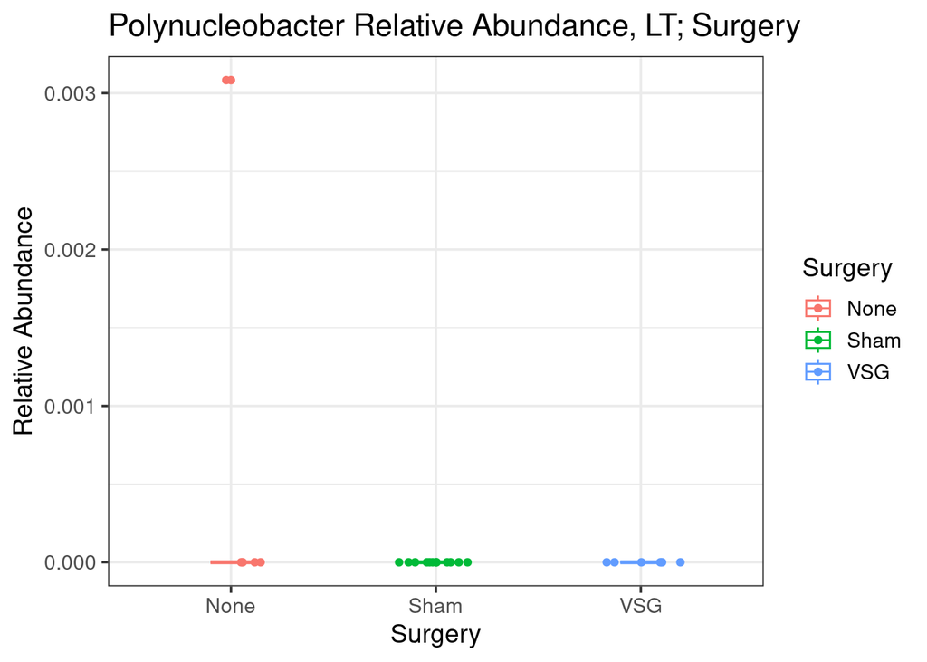

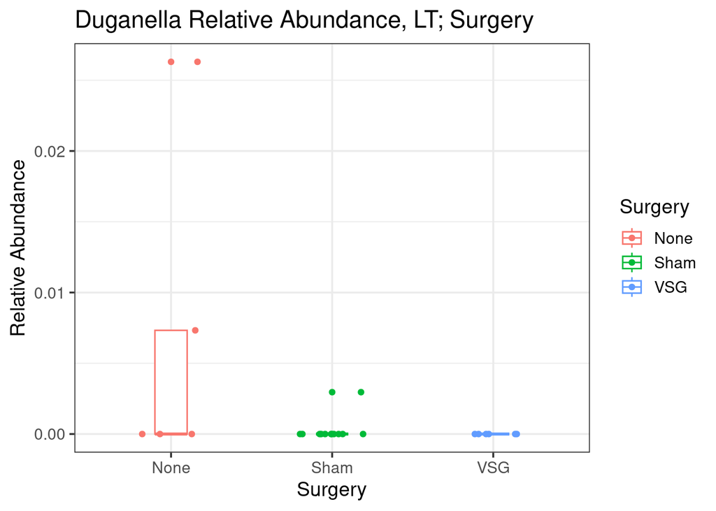

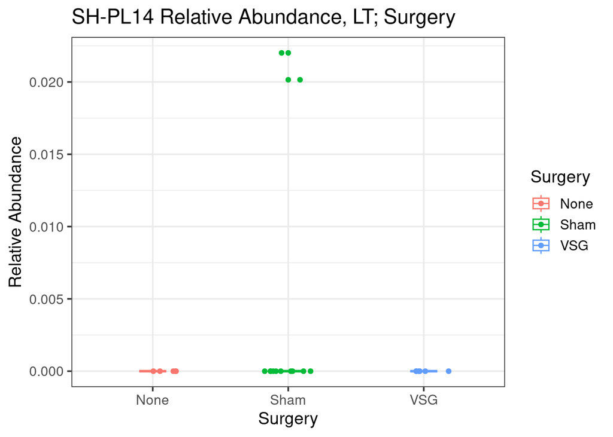

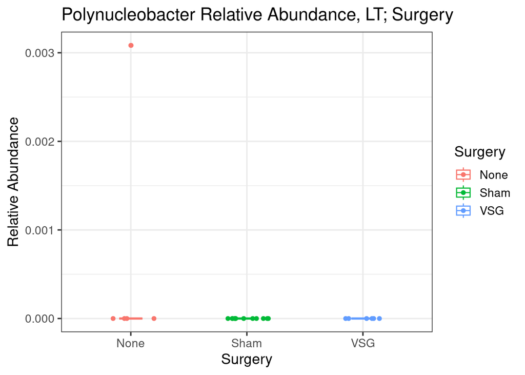

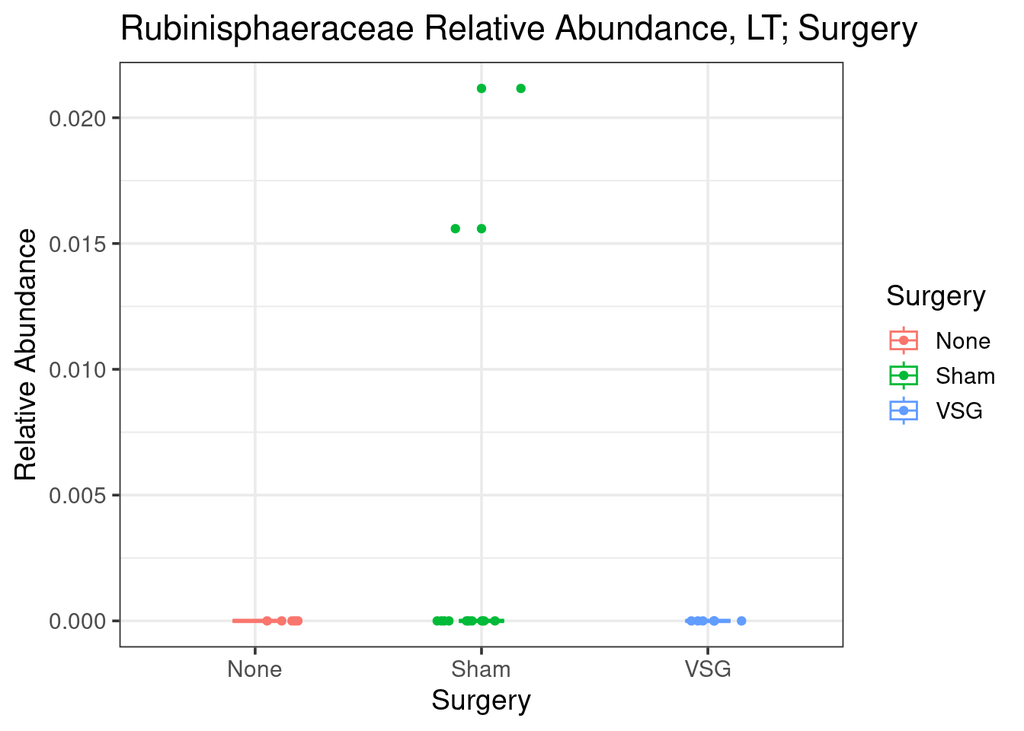

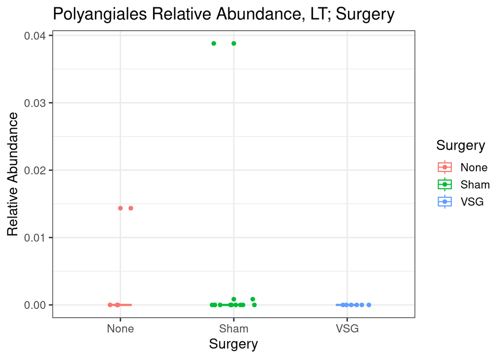

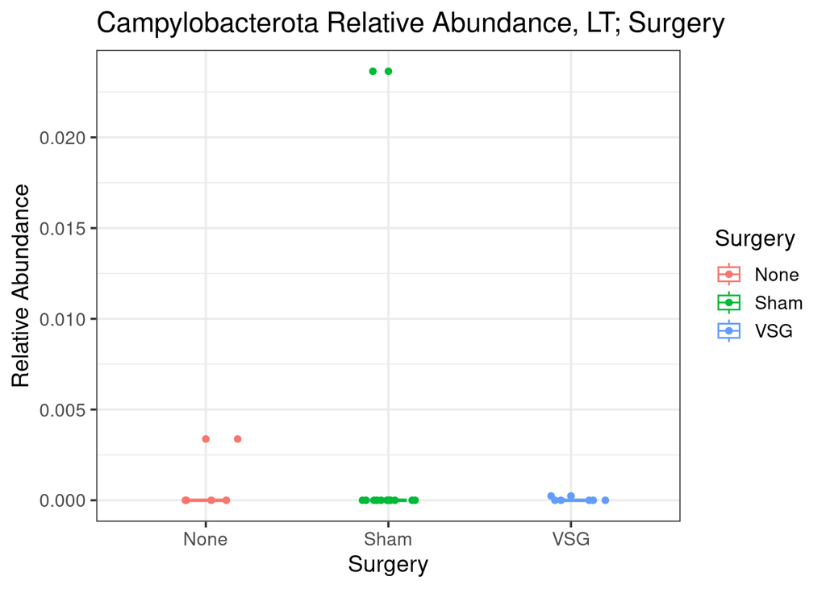

```r
surgery.labs <- c("No Surgery", "Sham Surgery", "VSG")
names(surgery.labs) <- c("None", "Sham", "VSG")

for (i in 1:length(LT.Q1.deseq.intersect.surgery$row)) {
  lt.graph.hfd %>%
  filter(OTU == LT.Q1.deseq.intersect.surgery$row[i]) %>%
  ggplot(aes(x = Surgery, y = Abundance, color = Surgery)) +
  geom_boxplot(width = 0.2) + geom_jitter(height = 0, width = 0.2) +
  labs(y="Relative Abundance", title = str_glue(LT.Q1.deseq.intersect.surgery$row[i], " Relative Abundance, LT; Surgery"),
       x="Surgery") +
  theme_bw(base_size = 14) -> p
  print(p)
}
```

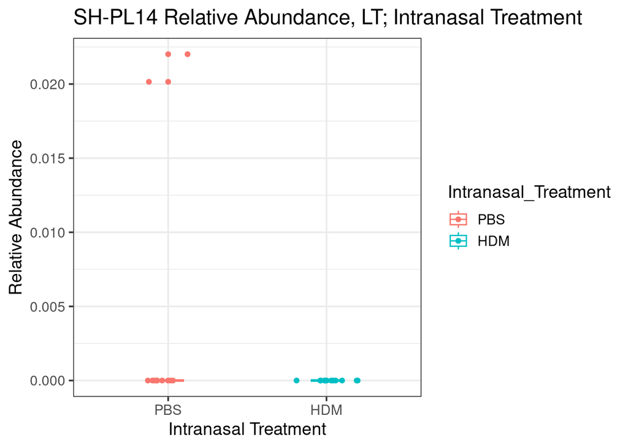

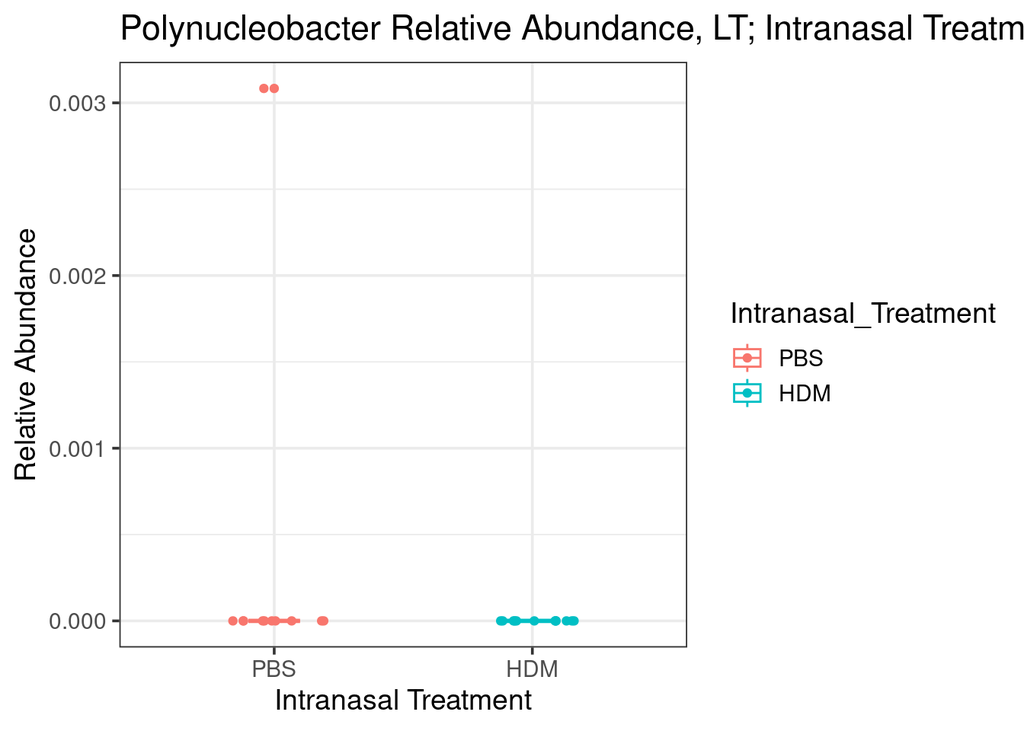

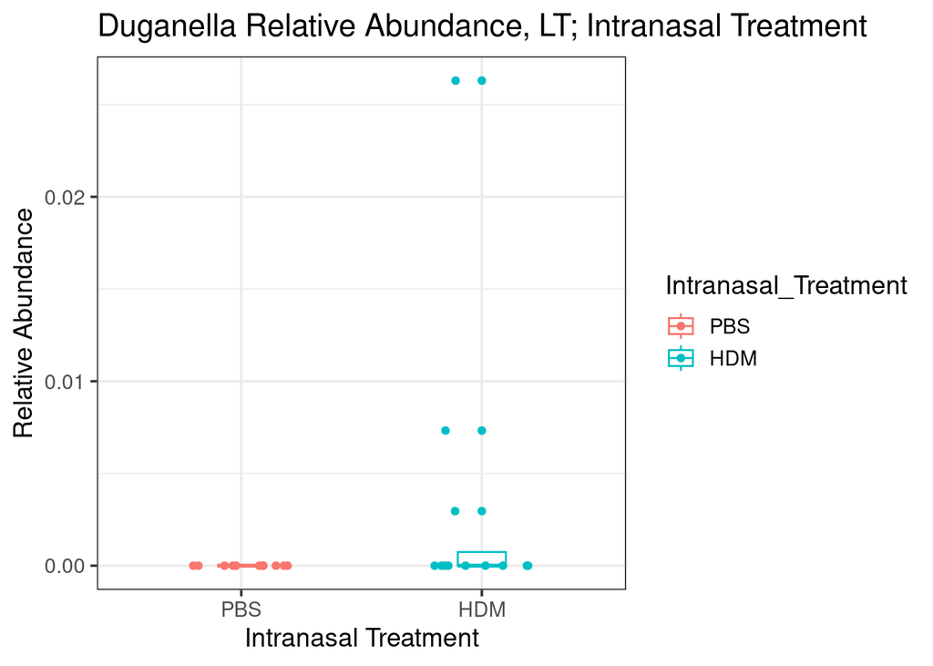

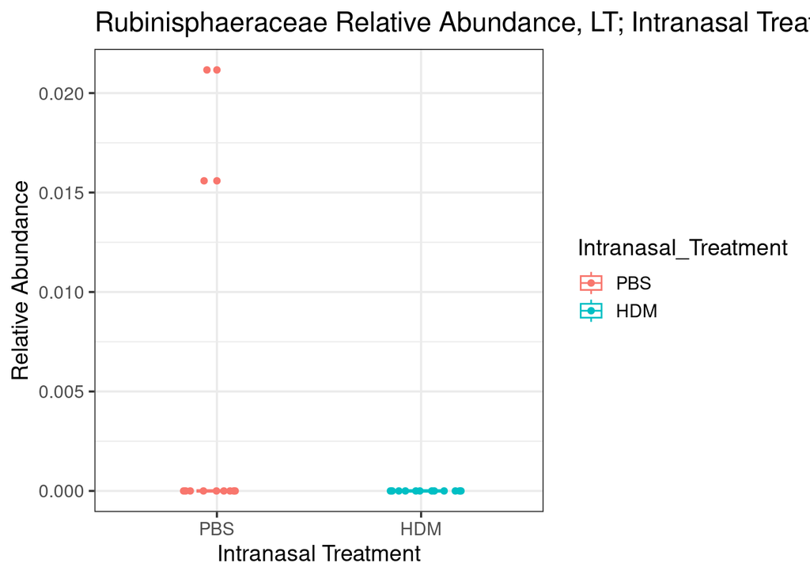

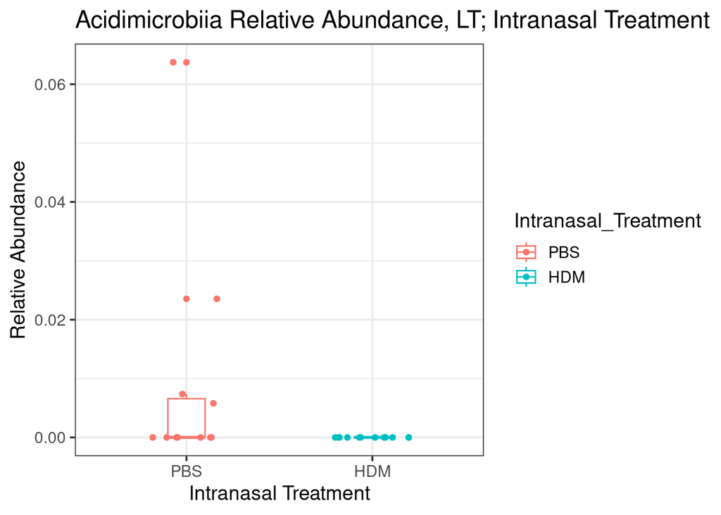

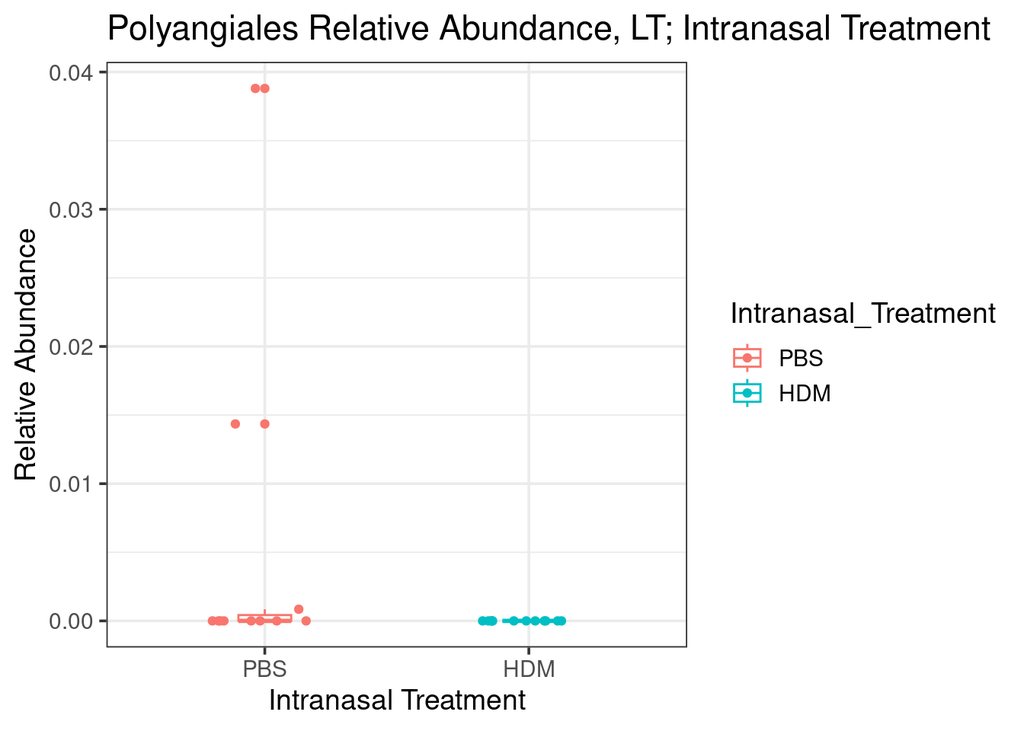

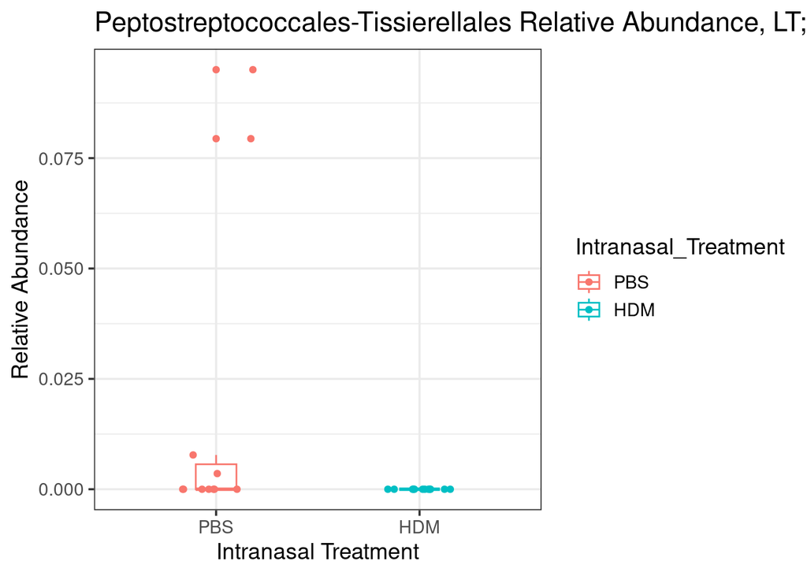

```r
for (i in 1:length(LT.Q1.deseq.intersect.intra$row)) {
  lt.graph.hfd %>%
  filter(OTU == LT.Q1.deseq.intersect.intra$row[i]) %>%
  ggplot(aes(x = Intranasal_Treatment, y = Abundance, color = Intranasal_Treatment)) +
  geom_boxplot(width = 0.2) + geom_jitter(height = 0, width = 0.2) +
  labs(y="Relative Abundance", title = str_glue(LT.Q1.deseq.intersect.intra$row[i], " Relative Abundance, LT; Intranasal Treatment"),
       x="Intranasal Treatment") +
  theme_bw(base_size = 14) -> p
  print(p)
}
```

Very spurious. This is not doing interpretation on; it’s unlikely that these spurious differences have biological meaning.

```r
lt.graph.hfd %>%
  filter(OTU %in% LT.Q1.deseq.intersect.surgery$row) %>%
  summary_by(Abundance ~ OTU + Surgery, FUN = median)
```

|  | OTU | Surgery | Abundance.median |
| --- | --- | --- | --- |
| 1 | Campylobacterota | None | 0 |
| 2 | Campylobacterota | Sham | 0 |
| 3 | Campylobacterota | VSG | 0 |
| 4 | Duganella | None | 0 |
| 5 | Duganella | Sham | 0 |
| 6 | Duganella | VSG | 0 |
| 7 | Polyangiales | None | 0 |
| 8 | Polyangiales | Sham | 0 |
| 9 | Polyangiales | VSG | 0 |
| 10 | Polynucleobacter | None | 0 |

[output cut: 8 more lines]

```r
lt.graph.hfd %>%
  filter(OTU %in% LT.Q1.deseq.intersect.intra$row) %>%
  summary_by(Abundance ~ OTU + Intranasal_Treatment, FUN = median)
```

|  | OTU | Intranasal_Treatment | Abundance.median |
| --- | --- | --- | --- |
| 1 | Acidimicrobiia | PBS | 0 |
| 2 | Acidimicrobiia | HDM | 0 |
| 3 | Duganella | PBS | 0 |
| 4 | Duganella | HDM | 0 |
| 5 | Peptostreptococcales-Tissierellales | PBS | 0 |
| 6 | Peptostreptococcales-Tissierellales | HDM | 0 |
| 7 | Polyangiales | PBS | 0 |
| 8 | Polyangiales | HDM | 0 |
| 9 | Polynucleobacter | PBS | 0 |
| 10 | Polynucleobacter | HDM | 0 |

[output cut: 4 more lines]

# 6 Lung Tissue Question 2: Intranasal_Treatment * Diet, No surgery group

## 6.1 Make TSE objects

```r
meta.lt %>% filter(Surgery == "None")
```

| Label | Concentration-(ng/uL) | Sample_type | Type | Sequencing_Run | Mouse | Cage-Mouse | Genotype | Sex | Diet | Intranasal_Treatment | Surgery | Intranasal_Dose | Cohort | Cage | Week | Lung_index | Kit | DNA_ng_ul_raw | Sample_Label | Cage_Notation | Feces_weight | Orig_label | Notes | Glucose_tolerance_wk0_0m | Glucose_tolerance_wk0_10m | Glucose_tolerance_wk0_30m | Glucose_tolerance_wk0_90m | Weight_g_wk0 | Glucose_tolerance_wk10_0m | … |
| --- | --- | --- | --- | --- | --- | --- | --- | --- | --- | --- | --- | --- | --- | --- | --- | --- | --- | --- | --- | --- | --- | --- | --- | --- | --- | --- | --- | --- | --- | --- |
| JI-646 | NA | Lung Tissue | True Sample | 2 | JI-646 | 1420953-2 | WT | Male | Normal_Chow | HDM | None | 50ug/40ul | 1 | 1420953 | 10 | 9 | BT_1 | 730 | NA | NA | NA | NA | NA | NA | NA | NA | NA | 25.06 | NA | … |
| JI-647 | NA | Lung Tissue | True Sample | 2 | JI-647 | 1420953-4 | WT | Male | Normal_Chow | PBS | None | 40ul | 1 | 1420953 | 10 | 21 | BT_1 | 408 | NA | NA | NA | NA | NA | NA | NA | NA | NA | 25.34 | NA | … |
| JI-648 | NA | Lung Tissue | True Sample | 2 | JI-648 | 1420953-3 | WT | Male | Normal_Chow | PBS | None | 40ul | 1 | 1420953 | 10 | 3 | BT_1 | 446 | NA | NA | NA | NA | NA | NA | NA | NA | NA | 25.38 | NA | … |
| JI-649 | NA | Lung Tissue | True Sample | 2 | JI-649 | 1420953-1 | WT | Male | Normal_Chow | HDM | None | 50ug/40ul | 1 | 1420953 | 10 | 17 | BT_1 | 345 | NA | NA | NA | NA | NA | NA | NA | NA | NA | 25.09 | NA | … |
| JI-650 | NA | Lung Tissue | True Sample | 1 | JI-650 | 1420961-1 | WT | Female | High_Fat_Diet | HDM | None | 50ug/40ul | 1 | 1420961 | 10 | 16 | BT_1 | 403 | NA | NA | NA | NA | NA | NA | NA | NA | NA | 19.04 | NA | … |
| JI-651 | NA | Lung Tissue | True Sample | 2 | JI-651 | 1420958-2 | KO | Male | High_Fat_Diet | PBS | None | 40ul | 1 | 1420958 | 10 | 51 | BT_2 | 500 | NA | NA | NA | NA | NA | 204 | 297 | 249 | 190 | 27.40 | 231 | … |
| JI-652 | NA | Lung Tissue | True Sample | 2 | JI-652 | 1420958-1 | KO | Male | High_Fat_Diet | HDM | None | 50ug/40ul | 1 | 1420958 | 10 | 8 | BT_1 | 383 | NA | NA | NA | NA | NA | 216 | 312 | 296 | 187 | 24.41 | 221 | … |
| JI-653 | NA | Lung Tissue | True Sample | 2 | JI-653 | 1420950-1 | KO | Female | High_Fat_Diet | HDM | None | 50ug/40ul | 1 | 1420950 | 10 | 18 | BT_1 | 660 | NA | NA | NA | NA | NA | NA | NA | NA | NA | NA | NA | … |
| JI-654 | NA | Lung Tissue | True Sample | 2 | JI-654 | 1420950-2 | WT | Female | High_Fat_Diet | HDM | None | 50ug/40ul | 1 | 1420950 | 10 | 39 | BT_1 | 149 | NA | NA | NA | NA | NA | NA | NA | NA | NA | NA | NA | … |
| JI-655 | NA | Lung Tissue | True Sample | 2 | JI-655 | 1420951-1 | WT | Male | High_Fat_Diet | PBS | None | 40ul | 1 | 1420951 | 10 | 29 | BT_1 | 226 | NA | NA | NA | NA | NA | NA | NA | NA | NA | NA | NA | … |

[output cut: 16 more lines]

```r
ps_genus.prune %>% subset_samples(Surgery == "None")  %>%
  mia::makeTreeSummarizedExperimentFromPhyloseq() -> tse.LT.Q2.Genus
tse.LT.Q2.Genus
```

```
## class: TreeSummarizedExperiment
## dim: 52 26
## metadata(0):
## assays(1): counts
## rownames(52): Rhodococcus Helicobacter ... Bifidobacterium Rhodoluna
## rowData names(6): Kingdom Phylum ... Family Genus
## colnames(26): SRR29054924 SRR29054925 ... SRR29054931 SRR29055148
## colData names(42): Label Qubit_ng_ul ... Concentration..ng.uL. is.neg
## reducedDimNames(0):
## mainExpName: NULL
## altExpNames(0):
## rowLinks: NULL
## rowTree: NULL
## colLinks: NULL
## colTree: NULL
```

```r
ps_Family.prune %>% subset_samples(Surgery == "None")  %>%
  mia::makeTreeSummarizedExperimentFromPhyloseq() -> tse.LT.Q2.Family
tse.LT.Q2.Family
```

```
## class: TreeSummarizedExperiment
## dim: 43 26
## metadata(0):
## assays(1): counts
## rownames(43): Nocardiaceae Ruminococcaceae ... Bifidobacteriaceae
##   Microbacteriaceae
## rowData names(6): Kingdom Phylum ... Family Genus
## colnames(26): SRR29054924 SRR29054925 ... SRR29054931 SRR29055148
## colData names(42): Label Qubit_ng_ul ... Concentration..ng.uL. is.neg
## reducedDimNames(0):
## mainExpName: NULL
## altExpNames(0):
## rowLinks: NULL
## rowTree: NULL
## colLinks: NULL
## colTree: NULL
```

```r
ps_Order.prune %>% subset_samples(Surgery == "None")  %>%
  mia::makeTreeSummarizedExperimentFromPhyloseq() -> tse.LT.Q2.Order
tse.LT.Q2.Order
```

```
## class: TreeSummarizedExperiment
## dim: 39 26
## metadata(0):
## assays(1): counts
## rownames(39): Corynebacteriales Chlamydiales ... Micrococcales
##   Bifidobacteriales
## rowData names(6): Kingdom Phylum ... Family Genus
## colnames(26): SRR29054924 SRR29054925 ... SRR29054931 SRR29055148
## colData names(42): Label Qubit_ng_ul ... Concentration..ng.uL. is.neg
## reducedDimNames(0):
## mainExpName: NULL
## altExpNames(0):
## rowLinks: NULL
## rowTree: NULL
## colLinks: NULL
## colTree: NULL
```

```r
ps_Class.prune %>% subset_samples(Surgery == "None")  %>%
  mia::makeTreeSummarizedExperimentFromPhyloseq() -> tse.LT.Q2.Class
tse.LT.Q2.Class
```

```
## class: TreeSummarizedExperiment
## dim: 23 26
## metadata(0):
## assays(1): counts
## rownames(23): Actinobacteria Chlamydiae ... Bacilli Acidimicrobiia
## rowData names(6): Kingdom Phylum ... Family Genus
## colnames(26): SRR29054924 SRR29054925 ... SRR29054931 SRR29055148
## colData names(42): Label Qubit_ng_ul ... Concentration..ng.uL. is.neg
## reducedDimNames(0):
## mainExpName: NULL
## altExpNames(0):
## rowLinks: NULL
## rowTree: NULL
## colLinks: NULL
## colTree: NULL
```

```r
ps_Phylum.prune %>% subset_samples(Surgery == "None")  %>%
  mia::makeTreeSummarizedExperimentFromPhyloseq() -> tse.LT.Q2.Phylum
tse.LT.Q2.Phylum
```

```
## class: TreeSummarizedExperiment
## dim: 14 26
## metadata(0):
## assays(1): counts
## rownames(14): Actinobacteriota Verrucomicrobiota ... Patescibacteria
##   Firmicutes
## rowData names(6): Kingdom Phylum ... Family Genus
## colnames(26): SRR29054924 SRR29054925 ... SRR29054931 SRR29055148
## colData names(42): Label Qubit_ng_ul ... Concentration..ng.uL. is.neg
## reducedDimNames(0):
## mainExpName: NULL
## altExpNames(0):
## rowLinks: NULL
## rowTree: NULL
## colLinks: NULL
## colTree: NULL
```

## 6.2 ANCOM II

### 6.2.1 Genus

```r
set.seed(123) # Set seed for reproducibility

# Genus level
LT.Q2.Genus <- ANCOMBC::ancom(data=tse.LT.Q2.Genus, assay_name="counts", tax_level="Genus",
                               p_adj_method="holm", prv_cut=0, lib_cut=0,
                               main_var="Intranasal_Treatment", adj_formula="Diet",
                               alpha = 0.05, struc_zero=TRUE,
                               n_cl = n_cl_requested)
```

```
## 'ancom' has been fully evolved to 'ancombc2'.
## Explore the enhanced capabilities of our refined method!
```

```r
res.LT.Q2.Genus = LT.Q2.Genus$res
res.LT.Q2.Genus %>% filter(detected_0.7 == TRUE) -> tab.LT.Q2.Genus.sig
tab.LT.Q2.Genus.sig
```

| taxon | W | detected_0.9 | detected_0.8 | detected_0.7 | detected_0.6 |
| --- | --- | --- | --- | --- | --- |
| Pseudarcicella | Inf | TRUE | TRUE | TRUE | TRUE |
| Pirellula | Inf | TRUE | TRUE | TRUE | TRUE |

Since this is based on structural zeroes, switching the order will yield different results.

### 6.2.2 Family

```r
# Family level
LT.Q2.Family <- ANCOMBC::ancom(data=tse.LT.Q2.Family, assay_name="counts", tax_level="Family",
                               p_adj_method="holm", prv_cut=0, lib_cut=0,
                               main_var="Intranasal_Treatment", adj_formula="Diet",
                               alpha = 0.05, struc_zero=TRUE,
                               n_cl = n_cl_requested)
```

```
## 'ancom' has been fully evolved to 'ancombc2'.
## Explore the enhanced capabilities of our refined method!
```

```r
res.LT.Q2.Family = LT.Q2.Family$res
res.LT.Q2.Family %>% filter(detected_0.7 == TRUE)  -> tab.LT.Q2.Family.sig
tab.LT.Q2.Family.sig
```

| taxon | W | detected_0.9 | detected_0.8 | detected_0.7 | detected_0.6 |
| --- | --- | --- | --- | --- | --- |
| Pirellulaceae | Inf | TRUE | TRUE | TRUE | TRUE |

Still all structural zeroes.

### 6.2.3 Order

```r
set.seed(123) # Set seed for reproducibility

# Order level
LT.Q2.Order <- ANCOMBC::ancom(data=tse.LT.Q2.Order, assay_name="counts", tax_level="Order",
                               p_adj_method="holm", prv_cut=0,  lib_cut=0,
                               main_var="Intranasal_Treatment", adj_formula="Diet",
                               alpha = 0.05, struc_zero=TRUE,
                               n_cl = n_cl_requested)
```

```
## 'ancom' has been fully evolved to 'ancombc2'.
## Explore the enhanced capabilities of our refined method!
```

```r
res.LT.Q2.Order = LT.Q2.Order$res
res.LT.Q2.Order %>% filter(detected_0.7 == TRUE) -> tab.LT.Q2.Order.sig
tab.LT.Q2.Order.sig
```

| taxon | W | detected_0.9 | detected_0.8 | detected_0.7 | detected_0.6 |
| --- | --- | --- | --- | --- | --- |
| Pirellulales | Inf | TRUE | TRUE | TRUE | TRUE |
| Candidatus Nomurabacteria | Inf | TRUE | TRUE | TRUE | TRUE |

### 6.2.4 Class

```r
set.seed(123) # Set seed for reproducibility

# Class level
LT.Q2.Class <- ANCOMBC::ancom(data=tse.LT.Q2.Class, assay_name="counts", tax_level="Class",
                               p_adj_method="holm", prv_cut=0, lib_cut=0,
                               main_var="Intranasal_Treatment", adj_formula="Diet",
                               alpha = 0.05, struc_zero=TRUE,
                               n_cl = n_cl_requested)
```

```
## 'ancom' has been fully evolved to 'ancombc2'.
## Explore the enhanced capabilities of our refined method!
```

```r
res.LT.Q2.Class = LT.Q2.Class$res
res.LT.Q2.Class %>% filter(detected_0.7 == TRUE) -> tab.LT.Q2.Class.sig
tab.LT.Q2.Class.sig
```

| taxon | W | detected_0.9 | detected_0.8 | detected_0.7 | detected_0.6 |
| --- | --- | --- | --- | --- | --- |

### 6.2.5 Phylum

```r
set.seed(123) # Set seed for reproducibility

# Phylum level
LT.Q2.Phylum <- ANCOMBC::ancom(data=tse.LT.Q2.Phylum, assay_name="counts", tax_level="Phylum",
                               p_adj_method="holm", prv_cut=0, lib_cut=0,
                               main_var="Intranasal_Treatment", adj_formula="Diet",
                               alpha = 0.05, struc_zero=TRUE,
                               n_cl = n_cl_requested)
```

```
## 'ancom' has been fully evolved to 'ancombc2'.
## Explore the enhanced capabilities of our refined method!
```

```r
res.LT.Q2.Phylum = LT.Q2.Phylum$res
res.LT.Q2.Phylum %>% filter(detected_0.7 == TRUE)  -> tab.LT.Q2.Phylum.sig
tab.LT.Q2.Phylum.sig
```

| taxon | W | detected_0.9 | detected_0.8 | detected_0.7 | detected_0.6 |
| --- | --- | --- | --- | --- | --- |

### 6.2.6 Aggregate Results

```r
tab.LT.Q2.Genus.sig$Tax_rank <- "Genus"
tab.LT.Q2.Family.sig$Tax_rank <- "Family"
tab.LT.Q2.Order.sig$Tax_rank <- "Order"

rbind(tab.LT.Q2.Genus.sig,
      tab.LT.Q2.Family.sig,
      tab.LT.Q2.Order.sig) -> tab.LT.Q2

tab.LT.Q2$Test <- "ANCOM II, Lung Tissue: no surgery group, intranasal treatment * diet. Structural zeroes from intranasal treatment"

tab.LT.Q2
```

| taxon | W | detected_0.9 | detected_0.8 | detected_0.7 | detected_0.6 | Tax_rank | Test |
| --- | --- | --- | --- | --- | --- | --- | --- |
| Pseudarcicella | Inf | TRUE | TRUE | TRUE | TRUE | Genus | ANCOM II, Lung Tissue: no surgery group, intranasal treatment * diet. Structural zeroes from intranasal treatment |
| Pirellula | Inf | TRUE | TRUE | TRUE | TRUE | Genus | ANCOM II, Lung Tissue: no surgery group, intranasal treatment * diet. Structural zeroes from intranasal treatment |
| Pirellulaceae | Inf | TRUE | TRUE | TRUE | TRUE | Family | ANCOM II, Lung Tissue: no surgery group, intranasal treatment * diet. Structural zeroes from intranasal treatment |
| Pirellulales | Inf | TRUE | TRUE | TRUE | TRUE | Order | ANCOM II, Lung Tissue: no surgery group, intranasal treatment * diet. Structural zeroes from intranasal treatment |
| Candidatus Nomurabacteria | Inf | TRUE | TRUE | TRUE | TRUE | Order | ANCOM II, Lung Tissue: no surgery group, intranasal treatment * diet. Structural zeroes from intranasal treatment |

## 6.3 DESeq2

### 6.3.1 Genus

```r
ds.LT.Q2_Genus <- DESeq2::DESeqDataSet(tse.LT.Q2.Genus, ~ Intranasal_Treatment + Diet + Intranasal_Treatment:Diet)
dds.LT.Q2_Genus <- DESeq2::DESeq(ds.LT.Q2_Genus)
```

```
## -- note: fitType='parametric', but the dispersion trend was not well captured by the
##    function: y = a/x + b, and a local regression fit was automatically substituted.
##    specify fitType='local' or 'mean' to avoid this message next time.
```

```
## -- replacing outliers and refitting for 20 genes
## -- DESeq argument 'minReplicatesForReplace' = 7
## -- original counts are preserved in counts(dds)
```

```r
DESeq2::summary(dds.LT.Q2_Genus)
```

```
## $samples
## # A tibble: 1 × 6
##   total_counts min_counts max_counts median_counts mean_counts stdev_counts
##          <dbl>      <dbl>      <dbl>         <dbl>       <dbl>        <dbl>
## 1       423978        578      41005        15582.      16307.       11281.
##
## $features
## # A tibble: 1 × 3
##   total singletons per_sample_avg
##   <int>      <int>          <dbl>
## 1    52          0           15.7
```

```r
resultsNames(dds.LT.Q2_Genus)
```

```
## [1] "Intercept"
## [2] "Intranasal_Treatment_HDM_vs_PBS"
## [3] "Diet_High_Fat_Diet_vs_Normal_Chow"
## [4] "Intranasal_TreatmentHDM.DietHigh_Fat_Diet"
```

```r
results(dds.LT.Q2_Genus, tidy = TRUE, contrast = c("Intranasal_Treatment", "HDM", "PBS")) %>% # tidy converts to df
  filter(padj < 0.05) -> LT.Q2.Genus.Res
LT.Q2.Genus.Res$Comparison <- c("Intranasal Treatment: HDM over PBS")

results(dds.LT.Q2_Genus, tidy = TRUE, contrast = c("Diet", "High_Fat_Diet", "Normal_Chow")) %>% # tidy converts to df
  filter(padj < 0.05) -> tmp
tmp$Comparison <- c("Diet: HFD over normal chow")
rbind(tmp, LT.Q2.Genus.Res) -> LT.Q2.Genus.Res

results(dds.LT.Q2_Genus, name = "Intranasal_TreatmentHDM.DietHigh_Fat_Diet", tidy = TRUE) %>%
  filter(padj < 0.05) -> tmp
tmp$Comparison <- c("Intranasal treatment (HDM) and diet (HFD)")
rbind(tmp, LT.Q2.Genus.Res) -> LT.Q2.Genus.Res

LT.Q2.Genus.Res
```

| row | baseMean | log2FoldChange | lfcSE | stat | pvalue | padj | Comparison |
| --- | --- | --- | --- | --- | --- | --- | --- |
| Helicobacter | 819.059721 | -30.00000 | 5.637395 | -5.321607 | 1.028548e-07 | 4.422755e-06 | Intranasal treatment (HDM) and diet (HFD) |
| Oscillibacter | 111.763098 | -26.60674 | 6.023264 | -4.417330 | 9.992766e-06 | 7.161483e-05 | Intranasal treatment (HDM) and diet (HFD) |
| Muribaculum | 292.033204 | -27.95754 | 5.758236 | -4.855227 | 1.202487e-06 | 1.034139e-05 | Intranasal treatment (HDM) and diet (HFD) |
| Bacteroides | 877.805580 | -25.74819 | 6.026154 | -4.272740 | 1.930859e-05 | 1.186099e-04 | Intranasal treatment (HDM) and diet (HFD) |
| Coriobacteriaceae UCG-002 | 114.527110 | -28.69531 | 5.639909 | -5.087902 | 3.620456e-07 | 7.177917e-06 | Intranasal treatment (HDM) and diet (HFD) |
| Acetatifactor | 56.262626 | -25.34121 | 6.025512 | -4.205652 | 2.603307e-05 | 1.399277e-04 | Intranasal treatment (HDM) and diet (HFD) |
| C39 | 53.520610 | 21.92063 | 6.068901 | 3.611960 | 3.038918e-04 | 1.306735e-03 | Intranasal treatment (HDM) and diet (HFD) |
| Aquabacterium | 83.754683 | 27.15258 | 5.402410 | 5.026012 | 5.007849e-07 | 7.177917e-06 | Intranasal treatment (HDM) and diet (HFD) |
| Limnohabitans | 12.328778 | 30.00000 | 6.142782 | 4.883781 | 1.040707e-06 | 1.034139e-05 | Intranasal treatment (HDM) and diet (HFD) |
| Pseudorhodobacter | 23.955245 | 15.32954 | 6.086627 | 2.518560 | 1.178356e-02 | 4.606303e-02 | Intranasal treatment (HDM) and diet (HFD) |

[output cut: 14 more lines]

### 6.3.2 Family

```r
ds.LT.Q2_Family <- DESeq2::DESeqDataSet(tse.LT.Q2.Family, ~ Intranasal_Treatment + Diet + Intranasal_Treatment:Diet)
dds.LT.Q2_Family <- DESeq2::DESeq(ds.LT.Q2_Family)
```

```
## -- note: fitType='parametric', but the dispersion trend was not well captured by the
##    function: y = a/x + b, and a local regression fit was automatically substituted.
##    specify fitType='local' or 'mean' to avoid this message next time.
```

```
## -- replacing outliers and refitting for 16 genes
## -- DESeq argument 'minReplicatesForReplace' = 7
## -- original counts are preserved in counts(dds)
```

```r
DESeq2::summary(dds.LT.Q2_Family)
```

```
## $samples
## # A tibble: 1 × 6
##   total_counts min_counts max_counts median_counts mean_counts stdev_counts
##          <dbl>      <dbl>      <dbl>         <dbl>       <dbl>        <dbl>
## 1       561608       1130      73777         18230      21600.       18181.
##
## $features
## # A tibble: 1 × 3
##   total singletons per_sample_avg
##   <int>      <int>          <dbl>
## 1    43          0           16.7
```

```r
resultsNames(dds.LT.Q2_Family)
```

```
## [1] "Intercept"
## [2] "Intranasal_Treatment_HDM_vs_PBS"
## [3] "Diet_High_Fat_Diet_vs_Normal_Chow"
## [4] "Intranasal_TreatmentHDM.DietHigh_Fat_Diet"
```

```r
results(dds.LT.Q2_Family, tidy = TRUE, contrast = c("Intranasal_Treatment", "HDM", "PBS")) %>% # tidy converts to df
  filter(padj < 0.05) -> LT.Q2.Family.Res
LT.Q2.Family.Res$Comparison <- c("Intranasal Treatment: HDM over PBS")

results(dds.LT.Q2_Family, tidy = TRUE, contrast = c("Diet", "High_Fat_Diet", "Normal_Chow")) %>% # tidy converts to df
  filter(padj < 0.05) -> tmp
tmp$Comparison <- c("Diet: HFD over normal chow")
rbind(tmp, LT.Q2.Family.Res) -> LT.Q2.Family.Res

results(dds.LT.Q2_Family, name = "Intranasal_TreatmentHDM.DietHigh_Fat_Diet", tidy = TRUE) %>%
  filter(padj < 0.05) -> tmp
tmp$Comparison <- c("Intranasal treatment (HDM) and diet (HFD)")
rbind(tmp, LT.Q2.Family.Res) -> LT.Q2.Family.Res

LT.Q2.Family.Res
```

| row | baseMean | log2FoldChange | lfcSE | stat | pvalue | padj | Comparison |
| --- | --- | --- | --- | --- | --- | --- | --- |
| Helicobacteraceae | 819.05972 | -30.00000 | 4.812864 | -6.233294 | 4.567264e-10 | 1.598543e-08 | Intranasal treatment (HDM) and diet (HFD) |
| Prevotellaceae | 41.79851 | 20.18041 | 6.072370 | 3.323316 | 8.895399e-04 | 4.447700e-03 | Intranasal treatment (HDM) and diet (HFD) |
| Bacteroidaceae | 877.80558 | -25.67330 | 5.168884 | -4.966894 | 6.803375e-07 | 5.952953e-06 | Intranasal treatment (HDM) and diet (HFD) |
| Atopobiaceae | 114.52711 | -28.67965 | 5.446996 | -5.265223 | 1.400191e-07 | 2.054498e-06 | Intranasal treatment (HDM) and diet (HFD) |
| Sphingomonadaceae | 80.14162 | 25.64427 | 4.909925 | 5.222945 | 1.760998e-07 | 2.054498e-06 | Intranasal treatment (HDM) and diet (HFD) |
| Verrucomicrobiaceae | 65.06057 | 21.13381 | 6.040181 | 3.498871 | 4.672330e-04 | 2.725526e-03 | Intranasal treatment (HDM) and diet (HFD) |
| Streptococcaceae | 299.34149 | 30.00000 | 6.114857 | 4.906084 | 9.291288e-07 | 6.503901e-06 | Intranasal treatment (HDM) and diet (HFD) |
| Parachlamydiaceae | 96.08566 | 21.07238 | 4.680112 | 4.502538 | 6.714688e-06 | 1.175070e-04 | Diet: HFD over normal chow |
| Spirosomaceae | 108.17137 | 9.59363 | 3.002082 | 3.195659 | 1.395119e-03 | 1.627639e-02 | Diet: HFD over normal chow |
| Prevotellaceae | 41.79851 | -21.57005 | 4.723397 | -4.566640 | 4.956039e-06 | 1.175070e-04 | Diet: HFD over normal chow |

[output cut: 6 more lines]

### 6.3.3 Order

```r
ds.LT.Q2_Order <- DESeq2::DESeqDataSet(tse.LT.Q2.Order, ~ Intranasal_Treatment + Diet + Intranasal_Treatment:Diet)
dds.LT.Q2_Order <- DESeq2::DESeq(ds.LT.Q2_Order)
```

```
## -- note: fitType='parametric', but the dispersion trend was not well captured by the
##    function: y = a/x + b, and a local regression fit was automatically substituted.
##    specify fitType='local' or 'mean' to avoid this message next time.
```

```
## -- replacing outliers and refitting for 9 genes
## -- DESeq argument 'minReplicatesForReplace' = 7
## -- original counts are preserved in counts(dds)
```

```r
DESeq2::summary(dds.LT.Q2_Order)
```

```
## $samples
## # A tibble: 1 × 6
##   total_counts min_counts max_counts median_counts mean_counts stdev_counts
##          <dbl>      <dbl>      <dbl>         <dbl>       <dbl>        <dbl>
## 1       603298       1184      77113         19757      23204.       19018.
##
## $features
## # A tibble: 1 × 3
##   total singletons per_sample_avg
##   <int>      <int>          <dbl>
## 1    39          0           15.7
```

```r
resultsNames(dds.LT.Q2_Order)
```

```
## [1] "Intercept"
## [2] "Intranasal_Treatment_HDM_vs_PBS"
## [3] "Diet_High_Fat_Diet_vs_Normal_Chow"
## [4] "Intranasal_TreatmentHDM.DietHigh_Fat_Diet"
```

```r
results(dds.LT.Q2_Order, tidy = TRUE, contrast = c("Intranasal_Treatment", "HDM", "PBS")) %>% # tidy converts to df
  filter(padj < 0.05) -> LT.Q2.Order.Res
LT.Q2.Order.Res$Comparison <- c("Intranasal Treatment: HDM over PBS")

results(dds.LT.Q2_Order, tidy = TRUE, contrast = c("Diet", "High_Fat_Diet", "Normal_Chow")) %>% # tidy converts to df
  filter(padj < 0.05) -> tmp
tmp$Comparison <- c("Diet: HFD over normal chow")
rbind(tmp, LT.Q2.Order.Res) -> LT.Q2.Order.Res

results(dds.LT.Q2_Order, name = "Intranasal_TreatmentHDM.DietHigh_Fat_Diet", tidy = TRUE) %>%
  filter(padj < 0.05) -> tmp
tmp$Comparison <- c("Intranasal treatment (HDM) and diet (HFD)")
rbind(tmp, LT.Q2.Order.Res) -> LT.Q2.Order.Res

LT.Q2.Order.Res
```

| row | baseMean | log2FoldChange | lfcSE | stat | pvalue | padj | Comparison |
| --- | --- | --- | --- | --- | --- | --- | --- |
| Campylobacterales | 822.40917 | -30.000000 | 4.573003 | -6.560241 | 5.372098e-11 | 1.719071e-09 | Intranasal treatment (HDM) and diet (HFD) |
| Sphingomonadales | 80.46935 | 25.630182 | 4.860701 | 5.272939 | 1.342559e-07 | 2.148095e-06 | Intranasal treatment (HDM) and diet (HFD) |
| Myxococcales | 24.04062 | 26.752880 | 6.088469 | 4.394024 | 1.112715e-05 | 1.137240e-04 | Intranasal treatment (HDM) and diet (HFD) |
| 0319-6G20 | 64.20697 | 25.940997 | 5.976491 | 4.340506 | 1.421550e-05 | 1.137240e-04 | Intranasal treatment (HDM) and diet (HFD) |
| Gastranaerophilales | 53.73730 | 19.714048 | 6.070567 | 3.247480 | 1.164317e-03 | 7.451628e-03 | Intranasal treatment (HDM) and diet (HFD) |
| Cytophagales | 117.32116 | 9.595782 | 2.856127 | 3.359718 | 7.802212e-04 | 6.241770e-03 | Diet: HFD over normal chow |
| Myxococcales | 24.04062 | -21.478636 | 4.723289 | -4.547390 | 5.431529e-06 | 8.690446e-05 | Diet: HFD over normal chow |
| 0319-6G20 | 64.20697 | -22.340598 | 4.652072 | -4.802289 | 1.568617e-06 | 5.019575e-05 | Diet: HFD over normal chow |
| Gastranaerophilales | 53.73730 | -20.426884 | 4.725044 | -4.323110 | 1.538452e-05 | 1.641015e-04 | Diet: HFD over normal chow |
| Pirellulales | 33.38075 | 23.888933 | 4.007055 | 5.961719 | 2.495986e-09 | 3.993577e-08 | Intranasal Treatment: HDM over PBS |

[output cut: 1 more lines]

### 6.3.4 Class

```r
ds.LT.Q2_Class <- DESeq2::DESeqDataSet(tse.LT.Q2.Class, ~ Intranasal_Treatment + Diet + Intranasal_Treatment:Diet)
dds.LT.Q2_Class <- DESeq2::DESeq(ds.LT.Q2_Class)
```

```
## -- note: fitType='parametric', but the dispersion trend was not well captured by the
##    function: y = a/x + b, and a local regression fit was automatically substituted.
##    specify fitType='local' or 'mean' to avoid this message next time.
```

```
## -- replacing outliers and refitting for 2 genes
## -- DESeq argument 'minReplicatesForReplace' = 7
## -- original counts are preserved in counts(dds)
```

```r
DESeq2::summary(dds.LT.Q2_Class)
```

```
## $samples
## # A tibble: 1 × 6
##   total_counts min_counts max_counts median_counts mean_counts stdev_counts
##          <dbl>      <dbl>      <dbl>         <dbl>       <dbl>        <dbl>
## 1       631006       1184      80099         21029      24269.       19688.
##
## $features
## # A tibble: 1 × 3
##   total singletons per_sample_avg
##   <int>      <int>          <dbl>
## 1    23          0           10.8
```

```r
resultsNames(dds.LT.Q2_Class)
```

```
## [1] "Intercept"
## [2] "Intranasal_Treatment_HDM_vs_PBS"
## [3] "Diet_High_Fat_Diet_vs_Normal_Chow"
## [4] "Intranasal_TreatmentHDM.DietHigh_Fat_Diet"
```

```r
results(dds.LT.Q2_Class, tidy = TRUE, contrast = c("Intranasal_Treatment", "HDM", "PBS")) %>% # tidy converts to df
  filter(padj < 0.05) -> LT.Q2.Class.Res
LT.Q2.Class.Res$Comparison <- c("Intranasal Treatment: HDM over PBS")

results(dds.LT.Q2_Class, tidy = TRUE, contrast = c("Diet", "High_Fat_Diet", "Normal_Chow")) %>% # tidy converts to df
  filter(padj < 0.05) -> tmp
tmp$Comparison <- c("Diet: HFD over normal chow")
rbind(tmp, LT.Q2.Class.Res) -> LT.Q2.Class.Res

results(dds.LT.Q2_Class, name = "Intranasal_TreatmentHDM.DietHigh_Fat_Diet", tidy = TRUE) %>%
  filter(padj < 0.05) -> tmp
tmp$Comparison <- c("Intranasal treatment (HDM) and diet (HFD)")
rbind(tmp, LT.Q2.Class.Res) -> LT.Q2.Class.Res

LT.Q2.Class.Res
```

| row | baseMean | log2FoldChange | lfcSE | stat | pvalue | padj | Comparison |
| --- | --- | --- | --- | --- | --- | --- | --- |
| Campylobacteria | 235.26509 | -28.87191 | 4.526052 | -6.379049 | 1.781912e-10 | 3.742016e-09 | Intranasal treatment (HDM) and diet (HFD) |
| Anaerolineae | 33.55790 | -23.01722 | 6.033149 | -3.815126 | 1.361136e-04 | 4.763976e-04 | Intranasal treatment (HDM) and diet (HFD) |
| Bdellovibrionia | 23.76835 | -30.00000 | 5.585637 | -5.370918 | 7.833674e-08 | 8.225357e-07 | Intranasal treatment (HDM) and diet (HFD) |
| Myxococcia | 18.41649 | 25.79563 | 6.091729 | 4.234534 | 2.290258e-05 | 9.619084e-05 | Intranasal treatment (HDM) and diet (HFD) |
| Oligoflexia | 120.28887 | 24.66824 | 4.805940 | 5.132865 | 2.853639e-07 | 1.997548e-06 | Intranasal treatment (HDM) and diet (HFD) |
| Vampirivibrionia | 92.98697 | 22.82433 | 5.069739 | 4.502072 | 6.729418e-06 | 3.532944e-05 | Intranasal treatment (HDM) and diet (HFD) |
| Anaerolineae | 33.55790 | 21.47862 | 4.676218 | 4.593161 | 4.365813e-06 | 2.292052e-05 | Diet: HFD over normal chow |
| Bdellovibrionia | 23.76835 | 14.58241 | 4.299525 | 3.391633 | 6.947733e-04 | 2.918048e-03 | Diet: HFD over normal chow |
| Myxococcia | 18.41649 | -21.70600 | 4.723383 | -4.595435 | 4.318472e-06 | 2.292052e-05 | Diet: HFD over normal chow |
| Oligoflexia | 120.28887 | -23.52297 | 3.761930 | -6.252900 | 4.029008e-10 | 8.460918e-09 | Diet: HFD over normal chow |

[output cut: 4 more lines]

### 6.3.5 Phylum

```r
ds.LT.Q2_Phylum <- DESeq2::DESeqDataSet(tse.LT.Q2.Phylum, ~ Intranasal_Treatment + Diet + Intranasal_Treatment:Diet)
dds.LT.Q2_Phylum <- DESeq2::DESeq(ds.LT.Q2_Phylum)
```

```
## -- note: fitType='parametric', but the dispersion trend was not well captured by the
##    function: y = a/x + b, and a local regression fit was automatically substituted.
##    specify fitType='local' or 'mean' to avoid this message next time.
```

```
## -- replacing outliers and refitting for 1 genes
## -- DESeq argument 'minReplicatesForReplace' = 7
## -- original counts are preserved in counts(dds)
```

```r
DESeq2::summary(dds.LT.Q2_Phylum)
```

```
## $samples
## # A tibble: 1 × 6
##   total_counts min_counts max_counts median_counts mean_counts stdev_counts
##          <dbl>      <dbl>      <dbl>         <dbl>       <dbl>        <dbl>
## 1       633091       1184      80147         21029      24350.       19714.
##
## $features
## # A tibble: 1 × 3
##   total singletons per_sample_avg
##   <int>      <int>          <dbl>
## 1    14          0           8.31
```

```r
resultsNames(dds.LT.Q2_Phylum)
```

```
## [1] "Intercept"
## [2] "Intranasal_Treatment_HDM_vs_PBS"
## [3] "Diet_High_Fat_Diet_vs_Normal_Chow"
## [4] "Intranasal_TreatmentHDM.DietHigh_Fat_Diet"
```

```r
results(dds.LT.Q2_Phylum, tidy = TRUE, contrast = c("Intranasal_Treatment", "HDM", "PBS")) %>% # tidy converts to df
  filter(padj < 0.05) -> LT.Q2.Phylum.Res
LT.Q2.Phylum.Res$Comparison <- c("Intranasal Treatment: HDM over PBS")

results(dds.LT.Q2_Phylum, tidy = TRUE, contrast = c("Diet", "High_Fat_Diet", "Normal_Chow")) %>% # tidy converts to df
  filter(padj < 0.05)
```

| row | baseMean | log2FoldChange | lfcSE | stat | pvalue | padj |
| --- | --- | --- | --- | --- | --- | --- |

```r
results(dds.LT.Q2_Phylum, name = "Intranasal_TreatmentHDM.DietHigh_Fat_Diet", tidy = TRUE) %>%
  filter(padj < 0.05) -> tmp
tmp$Comparison <- c("Intranasal treatment (HDM) and diet (HFD)")
rbind(tmp, LT.Q2.Phylum.Res) -> LT.Q2.Phylum.Res

LT.Q2.Phylum.Res
```

| row | baseMean | log2FoldChange | lfcSE | stat | pvalue | padj | Comparison |
| --- | --- | --- | --- | --- | --- | --- | --- |
| Campylobacterota | 200.42127 | -28.65756 | 5.068024 | -5.654581 | 1.562266e-08 | 2.187172e-07 | Intranasal treatment (HDM) and diet (HFD) |
| Dependentiae | 42.83033 | -16.61429 | 3.965470 | -4.189741 | 2.792726e-05 | 3.909816e-04 | Intranasal Treatment: HDM over PBS |

### 6.3.6 Aggregate results

```r
rbind(LT.Q2.Genus.Res,
      LT.Q2.Family.Res,
      LT.Q2.Class.Res,
      LT.Q2.Order.Res,
      LT.Q2.Phylum.Res) -> LT.Q2.deseq

LT.Q2.deseq$Test <- "DESeq2, Lung Tissue: no surgery, intranasal treatment * diet"

LT.Q2.deseq
```

| row | baseMean | log2FoldChange | lfcSE | stat | pvalue | padj | Comparison | Test |
| --- | --- | --- | --- | --- | --- | --- | --- | --- |
| Helicobacter | 819.059721 | -30.000000 | 5.637395 | -5.321607 | 1.028548e-07 | 4.422755e-06 | Intranasal treatment (HDM) and diet (HFD) | DESeq2, Lung Tissue: no surgery, intranasal treatment * diet |
| Oscillibacter | 111.763098 | -26.606744 | 6.023264 | -4.417330 | 9.992766e-06 | 7.161483e-05 | Intranasal treatment (HDM) and diet (HFD) | DESeq2, Lung Tissue: no surgery, intranasal treatment * diet |
| Muribaculum | 292.033204 | -27.957545 | 5.758236 | -4.855227 | 1.202487e-06 | 1.034139e-05 | Intranasal treatment (HDM) and diet (HFD) | DESeq2, Lung Tissue: no surgery, intranasal treatment * diet |
| Bacteroides | 877.805580 | -25.748187 | 6.026154 | -4.272740 | 1.930859e-05 | 1.186099e-04 | Intranasal treatment (HDM) and diet (HFD) | DESeq2, Lung Tissue: no surgery, intranasal treatment * diet |
| Coriobacteriaceae UCG-002 | 114.527110 | -28.695308 | 5.639909 | -5.087902 | 3.620456e-07 | 7.177917e-06 | Intranasal treatment (HDM) and diet (HFD) | DESeq2, Lung Tissue: no surgery, intranasal treatment * diet |
| Acetatifactor | 56.262626 | -25.341208 | 6.025512 | -4.205652 | 2.603307e-05 | 1.399277e-04 | Intranasal treatment (HDM) and diet (HFD) | DESeq2, Lung Tissue: no surgery, intranasal treatment * diet |
| C39 | 53.520610 | 21.920627 | 6.068901 | 3.611960 | 3.038918e-04 | 1.306735e-03 | Intranasal treatment (HDM) and diet (HFD) | DESeq2, Lung Tissue: no surgery, intranasal treatment * diet |
| Aquabacterium | 83.754683 | 27.152577 | 5.402410 | 5.026012 | 5.007849e-07 | 7.177917e-06 | Intranasal treatment (HDM) and diet (HFD) | DESeq2, Lung Tissue: no surgery, intranasal treatment * diet |
| Limnohabitans | 12.328778 | 30.000000 | 6.142782 | 4.883781 | 1.040707e-06 | 1.034139e-05 | Intranasal treatment (HDM) and diet (HFD) | DESeq2, Lung Tissue: no surgery, intranasal treatment * diet |
| Pseudorhodobacter | 23.955245 | 15.329538 | 6.086627 | 2.518560 | 1.178356e-02 | 4.606303e-02 | Intranasal treatment (HDM) and diet (HFD) | DESeq2, Lung Tissue: no surgery, intranasal treatment * diet |

[output cut: 57 more lines]

## 6.4 Intersection

```r
tab.LT.Q2 %>% filter(taxon %in% LT.Q2.deseq$row) -> ancom.intersect.nosurgery
ancom.intersect.nosurgery
```

| taxon | W | detected_0.9 | detected_0.8 | detected_0.7 | detected_0.6 | Tax_rank | Test |
| --- | --- | --- | --- | --- | --- | --- | --- |
| Pseudarcicella | Inf | TRUE | TRUE | TRUE | TRUE | Genus | ANCOM II, Lung Tissue: no surgery group, intranasal treatment * diet. Structural zeroes from intranasal treatment |
| Pirellula | Inf | TRUE | TRUE | TRUE | TRUE | Genus | ANCOM II, Lung Tissue: no surgery group, intranasal treatment * diet. Structural zeroes from intranasal treatment |
| Pirellulaceae | Inf | TRUE | TRUE | TRUE | TRUE | Family | ANCOM II, Lung Tissue: no surgery group, intranasal treatment * diet. Structural zeroes from intranasal treatment |
| Pirellulales | Inf | TRUE | TRUE | TRUE | TRUE | Order | ANCOM II, Lung Tissue: no surgery group, intranasal treatment * diet. Structural zeroes from intranasal treatment |

*Pseudarcicella* is a genus that has been isolated from a skin of a [medical leech](https://www.microbiologyresearch.org/content/journal/ijsem/10.1099/ijs.0.037390-0). I really don’t think this has any biological significance… Let’s graph this just out of curiosity.

```r
LT.Q2.deseq %>% filter(row %in% tab.LT.Q2$taxon)
```

| row | baseMean | log2FoldChange | lfcSE | stat | pvalue | padj | Comparison | Test |
| --- | --- | --- | --- | --- | --- | --- | --- | --- |
| Pirellula | 32.46688 | -14.77780 | 4.784630 | -3.088597 | 2.011037e-03 | 1.080932e-02 | Diet: HFD over normal chow | DESeq2, Lung Tissue: no surgery, intranasal treatment * diet |
| Pseudarcicella | 41.53281 | 21.62682 | 4.007792 | 5.396193 | 6.806968e-08 | 1.013189e-06 | Intranasal Treatment: HDM over PBS | DESeq2, Lung Tissue: no surgery, intranasal treatment * diet |
| Pirellula | 32.46688 | 23.86010 | 4.007055 | 5.954524 | 2.608296e-09 | 1.121567e-07 | Intranasal Treatment: HDM over PBS | DESeq2, Lung Tissue: no surgery, intranasal treatment * diet |
| Pirellulaceae | 33.25979 | 23.89285 | 4.007055 | 5.962695 | 2.481106e-09 | 4.341936e-08 | Intranasal Treatment: HDM over PBS | DESeq2, Lung Tissue: no surgery, intranasal treatment * diet |
| Pirellulales | 33.38075 | 23.88893 | 4.007055 | 5.961719 | 2.495986e-09 | 3.993577e-08 | Intranasal Treatment: HDM over PBS | DESeq2, Lung Tissue: no surgery, intranasal treatment * diet |

## 6.5 Graph: Intersection

```r
LT.RA.Full %>% filter(Surgery == "None") -> lt.graph.none
head(lt.graph.none)
```

|  | OTU | Sample | Abundance | Label | Sample_type | Type | Sequencing_Run | Mouse | Genotype | Sex | Diet | Intranasal_Treatment | Surgery | Week |
| --- | --- | --- | --- | --- | --- | --- | --- | --- | --- | --- | --- | --- | --- | --- |
| 1 | Rhodococcus | SRR29055144 | 0.5980233 | JI-654 | Lung Tissue | True Sample | 2 | JI-654 | WT | Female | High_Fat_Diet | HDM | None | 10 |
| 2 | Rhodococcus | SRR29054924 | 0.5818182 | JI-685 | Lung Tissue | True Sample | 2 | JI-685 | KO | Female | Normal_Chow | HDM | None | 13 |
| 3 | Rhodococcus | SRR29054926 | 0.5242597 | JI-683 | Lung Tissue | True Sample | 2 | JI-683 | KO | Female | Normal_Chow | HDM | None | 13 |
| 4 | Rhodococcus | SRR29055151 | 0.4918022 | JI-647 | Lung Tissue | True Sample | 2 | JI-647 | WT | Male | Normal_Chow | PBS | None | 10 |
| 5 | Rhodococcus | SRR29055140 | 0.4840096 | JI-657 | Lung Tissue | True Sample | 2 | JI-657 | KO | Male | Normal_Chow | HDM | None | 10 |
| 6 | Rhodococcus | SRR29054932 | 0.4599487 | JI-677 | Lung Tissue | True Sample | 2 | JI-677 | WT | Female | Normal_Chow | HDM | None | 13 |

```r
tail(lt.graph.none)
```

|  | OTU | Sample | Abundance | Label | Sample_type | Type | Sequencing_Run | Mouse | Genotype | Sex | Diet | Intranasal_Treatment | Surgery | Week |
| --- | --- | --- | --- | --- | --- | --- | --- | --- | --- | --- | --- | --- | --- | --- |
| 4441 | Verrucomicrobiota | SRR29054937 | 0 | JI-672 | Lung Tissue | True Sample | 2 | JI-672 | WT | Female | High_Fat_Diet | HDM | None | 13 |
| 4442 | Verrucomicrobiota | SRR29055139 | 0 | JI-658 | Lung Tissue | True Sample | 2 | JI-658 | KO | Male | Normal_Chow | PBS | None | 10 |
| 4443 | Verrucomicrobiota | SRR29054932 | 0 | JI-677 | Lung Tissue | True Sample | 2 | JI-677 | WT | Female | Normal_Chow | HDM | None | 13 |
| 4444 | Verrucomicrobiota | SRR29054924 | 0 | JI-685 | Lung Tissue | True Sample | 2 | JI-685 | KO | Female | Normal_Chow | HDM | None | 13 |
| 4445 | Verrucomicrobiota | SRR29054926 | 0 | JI-683 | Lung Tissue | True Sample | 2 | JI-683 | KO | Female | Normal_Chow | HDM | None | 13 |
| 4446 | Verrucomicrobiota | SRR29054931 | 0 | JI-678 | Lung Tissue | True Sample | 1 | JI-678 | WT | Female | Normal_Chow | PBS | None | 13 |

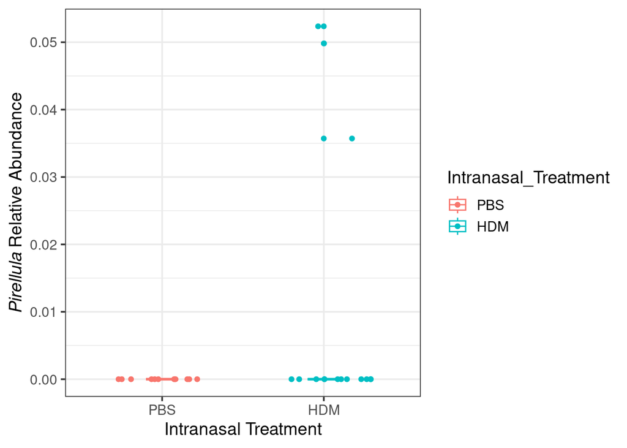

```r
lt.graph.none %>%
  filter(OTU == "Pirellula") %>%
  ggplot(aes(x = Intranasal_Treatment, y = Abundance, color = Intranasal_Treatment)) +
  geom_boxplot(width = 0.2) + geom_jitter(height = 0, width = 0.3) +
  labs(y="*Pirellula* Relative Abundance",
       x="Intranasal Treatment") +
  theme_bw(base_size = 14) + theme(axis.title.y = element_markdown(), title = element_markdown())
```

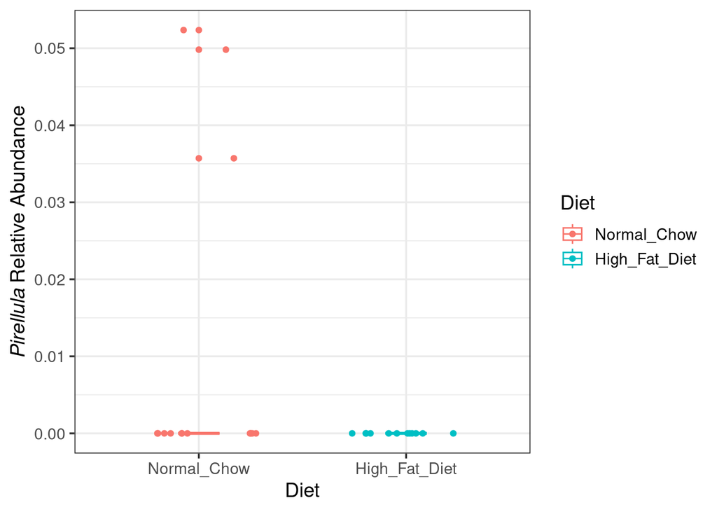

```r
lt.graph.none %>%
  filter(OTU == "Pirellula") %>%
  ggplot(aes(x = Diet, y = Abundance, color = Diet)) +
  geom_boxplot(width = 0.2) + geom_jitter(height = 0, width = 0.3) +
  labs(y="*Pirellula* Relative Abundance",
       x="Diet") +
  theme_bw(base_size = 14) + theme(axis.title.y = element_markdown(), title = element_markdown())
```

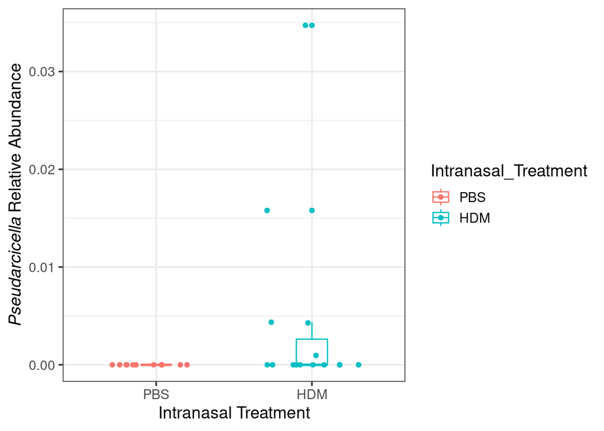

```r
lt.graph.none %>%
  filter(OTU == "Pseudarcicella") %>%
  ggplot(aes(x = Intranasal_Treatment, y = Abundance, color = Intranasal_Treatment)) +
  geom_boxplot(width = 0.2) + geom_jitter(height = 0, width = 0.3) +
  labs(y="*Pseudarcicella* Relative Abundance",
       x="Intranasal Treatment") +
  theme_bw(base_size = 14) + theme(axis.title.y = element_markdown(), title = element_markdown())
```

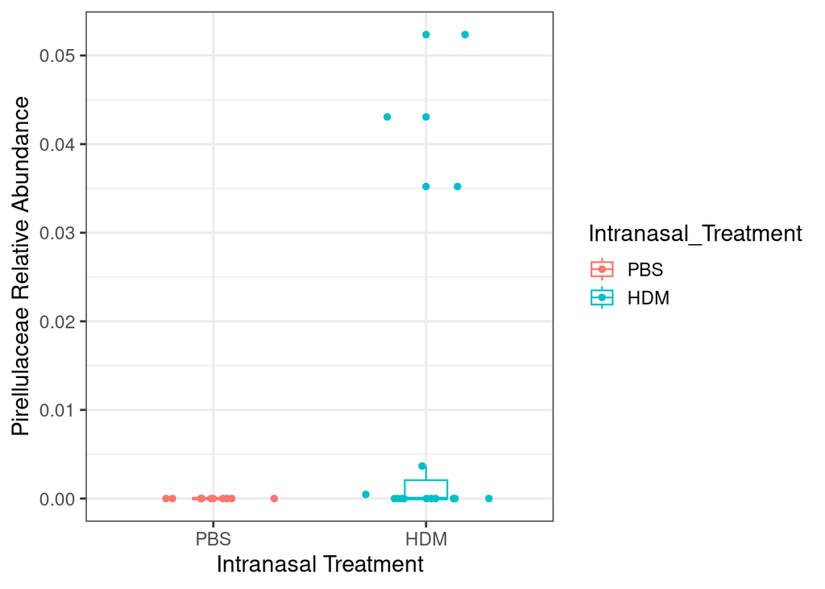

```r
lt.graph.none %>%
  filter(OTU == "Pirellulaceae") %>%
  ggplot(aes(x = Intranasal_Treatment, y = Abundance, color = Intranasal_Treatment)) +
  geom_boxplot(width = 0.2) + geom_jitter(height = 0, width = 0.3) +
  labs(y="Pirellulaceae Relative Abundance",
       x="Intranasal Treatment") +
  theme_bw(base_size = 14) + theme(axis.title.y = element_markdown(), title = element_markdown())
```

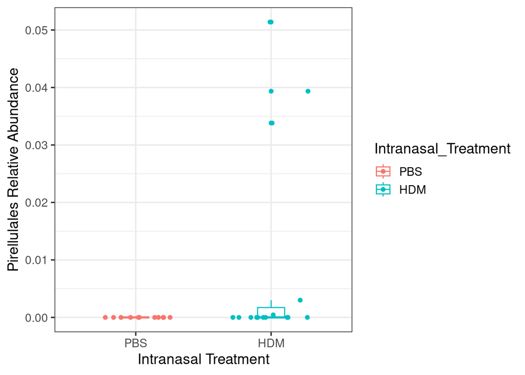

```r
lt.graph.none %>%
  filter(OTU == "Pirellulales") %>%
  ggplot(aes(x = Intranasal_Treatment, y = Abundance, color = Intranasal_Treatment)) +
  geom_boxplot(width = 0.2) + geom_jitter(height = 0, width = 0.3) +
  labs(y="Pirellulales Relative Abundance",
       x="Intranasal Treatment") +
  theme_bw(base_size = 14) + theme(axis.title.y = element_markdown(), title = element_markdown())
```

Very spurious. This is not worth doing interpretation on; it’s unlikely that these spurious differences have biological meaning.

```r
lt.graph.none %>%
  filter(OTU %in% ancom.intersect.nosurgery$taxon) %>%
  summary_by(Abundance ~ OTU + Intranasal_Treatment, FUN = median)
```

|  | OTU | Intranasal_Treatment | Abundance.median |
| --- | --- | --- | --- |
| 1 | Pirellula | PBS | 0 |
| 2 | Pirellula | HDM | 0 |
| 3 | Pirellulaceae | PBS | 0 |
| 4 | Pirellulaceae | HDM | 0 |
| 5 | Pirellulales | PBS | 0 |
| 6 | Pirellulales | HDM | 0 |
| 7 | Pseudarcicella | PBS | 0 |
| 8 | Pseudarcicella | HDM | 0 |

```r
lt.graph.none %>%
  filter(OTU == "Pirellula") %>%
  summary_by(Abundance ~ OTU + Diet, FUN = median)
```

|  | OTU | Diet | Abundance.median |
| --- | --- | --- | --- |
| 1 | Pirellula | Normal_Chow | 0 |
| 2 | Pirellula | High_Fat_Diet | 0 |